# Deep Learning - Project 2 - Convolutional Neural Networks - 2023/24

## Basic information

### Rules for completing the course

- The grade for this project is $50\%$ of the final grade for the Deep Learning course
- In order to pass the course, it is necessary to pass ($\geq 50\%$) each of the 2 projects

### Purpose of the project

- Getting acquainted with one of the most popular frameworks used in Deep Learning - TensorFlow
- Practical exercises related to Deep Learning (in particular Convolutional Neural Networks)
- Empirical confirmation of the influence of individual elements of the algorithm and data on the results (based on experimental comparative analyses)
- Improving programming skills

### Project prerequisites

- Student has the skills to write code in Python and is able to use Jupyter Notebook
- Student is able to search for information on the documentation of Python packages and use them in practice
- Student has knowledge of the basics of Deep Learning, in particular about the Convolutional Neural Networks (knowledge obtained during laboratories; introductory materials available on eKursy)

### Implementation of the project

- Individually or in groups of two

### Parts of the project

**Part 1** - Implementation of an image classifier ($40\%$)

**Part 2** - Experimental comparative analysis ($20\%$ for each subtask):

- Task's implementation ($10\%$)
- Task's description ($10\%$)

Maximum rating for the project - $100\%$.

**Note:** Some tasks, in addition to implementation, will require you to describe your observations and thoughts. You can do it in the form of Markdowns (this is the preferred form) or prepare a separate file with the report (in that case - preferably PDF).

**Note:** To get points from a given subtask in Part 2, you must provide both an implementation and a description. If one of the task parts (implementation or description) is missing, the latter does not count. The percentages show how each part contributes to the grade.

**Note:** Without correctly completing the Part 1, it will likely be difficult (or even impossible) to complete tasks in the Part 2.

### Technical requirements

- The implementation should be done in Python, using TensorFlow, preferably with the Keras API. You can use TensorFlow with GPU support, but it's not mandatory. If you want to use a different package or technology, please consult it via e-mail or during the classes.
- Preferred form - Jupyter Notebook(s) (e.g. this one). It is also possible to implement in regular Python files (.py).
- Some tasks require displaying data, images, tables, plots, etc. Suggested support packages - NumPy, matplotlib, pandas, scikit-learn (you can use others if you want)

### Deadline

- **Saturday, 2024-01-27** (by the end of the day)
- In case of delay, each subsequent week started will lower the grade by $20\%$. So the maximum grade for solutions sent in the period:
  - From 2024-01-28 to 2024-02-03 (by the end of the day) - $80\%$
  - From 2024-02-04 to 2024-02-10 (by the end of the day) - $60\%$
  - From 2024-02-11 - $40\%$ (project failed)

### Solution content

**Please:**

- Provide information about which dataset you used - put it in Notebook or in an e-mail
- Provide the source code performing tasks from the Part 1 and 2. As long as the Notebook is not too big (over a few MB) - please **don't** reset the Notebook(s) output. If I have problems while testing the code, I will be able to check your solutions at least by looking at the output. Alternatively, send me two notebooks - one with outputs filled in and the other without outputs.
- Attach also a list of packages with the versions you used when implementing the project (*pip freeze > requirements.txt*)
- If you are not using Markdowns in Notebook(s) or comments in case of regular Python files, please describe in the email where I should look for the code for specific parts of the tasks.
- If you decide to prepare a separate report (preffered PDF file), attach it as well.
- If the file structure is different than that proposed in the content of the tasks, provide information about the file structure - i.e. where should I put the dataset in order to run your code
- Provide any graphs, tables, files, resources etc. on the basis of which conclusions about the tasks were made, and are not visible in the Markdowns or output of the Notebook. Please describe in the report or in the e-mail what the attached materials relate to.
- Add files with model and parameters from Part 1, task 6) (as long as they do not occupy more than a few MB)

**Please DON'T:**

- Send the dataset - I'd rather avoid downloading mega- or gigabytes of data from each of you :)

### Delivery method

- Send the above-mentioned content (ZIP file preferred) to michal.wojcik@doctorate.put.poznan.pl
- Title: **[DL] Project 2 - [Student1_First_Name] [Student1_Surname] [Student1_ID], [Student2_First_Name] [Student2_Surname] [Student2_ID]**
- Title example: **[DL] Project 2 - Anna Nowak 123456, John Doe 789012**

### Project modifications

This document is a project proposal and describes the preferred way to complete and pass the second part of the Deep Learning Labs.

If you believe that introducing minor (e.g. changing the dataset, new task definition) or major modifications to this project or changing the approach (e.g. implementing a different concept that solves another practical problem - mainly for those who are more experienced in Deep Learning) will be more interesting and will allow you to better understand and learn about previously unknown issues related to the basics of Deep Learning (in particular Convolutional Neural Networks), please do not hesitate to present your proposal and modify the project definition.

In order for the proposed modifications to be accepted, the concept must be presented individually (by e-mail or during the class), then described in detail and approved via e-mail by the teacher.

## Part 1 - Implementation of an image classifier (40%)

The goal of the Part 1 is to implement an image classifier from scratch. The task consists in loading the data (images & labels), preprocessing, preparing the datasets for learning, preparing the model, conducting the learning process and evaluating the model on the test set. A more detailed scheme is presented below, broken down into subtasks.

### Data

Proposed datasets:

- Caltech 101 (137 MB)
- Caltech 256 (1.2 GB)

**Link to datasets:** https://www.vision.caltech.edu/datasets/

Both of the above collections consist of many JPG images containing an object from one of many classes. For each class of objects, there are from several dozen to several hundred examples of images.

If you decide you want to use a different dataset, here are some requirements:

- The size of the images should not be smaller than 100x100 pixels
- Images should be in color (RGB/RGBA), not grayscale
- Images should be in such a format that they can be easily loaded into numpy.array of pixels (png, jpg)
- The collection should contain at least 20 classes with at least 80 examples for each class
- Images must be labeled - that is, assigned exactly to 1 of N decision classes
- The classification problem cannot be *trivial* (e.g. it is possible to assign photos to classes by calculating the average pixel color)

As mentioned above, the proposed change of the dataset must be accepted by a teacher.

### Before you start

- Start by reading all the steps and see also the Part 2 - this will make it easier for you to plan the entire dataset processing flow and how to organize your code
- Implement tasks as a functions - it's always a good idea if your code is reusable and parameterizable, especially in that case, because some part of the source code from the Part 1 will be also useful in the Part 2
- Use Markdowns - they help organize the code and allow you to describe additional information. Each time the task includes a question or request to describe your conclusions, comments, observations, etc. your answer should be put in Markdowns (preferred form) or in the report file that you send after completing all of the tasks
- **Step verification** should also be implemented - it should be visible as the output of the cell(s) execution after implementing and executing the code that carries out the tasks specified in a given step
- The hints, order of subtasks, functions mentioned in the description below are only a suggestion - you can present your own approach and improvements, but in such a way that it is possible to observe the changes taking place between subsequent steps. Please, don't use *magic*, one-line functions that do all the steps at once - the aim of the project is also to familiarize you with the features offered by the packages (mainly TensorFlow with Keras API). If you have made any exceptions from the proposed approach (e.g. you loaded a dataset with the tensorflow_datasets package), please mention and describe this fact in the step 7)

### Steps to follow:

#### 1) Download the data and load it in the Notebook (5%)

**Note:** The *standard* dataset loading sequence is described below. You can also use *tensorflow_datasets* package for this purpose.

- Download the archive with the dataset
- Create directory "data" and extract downloaded files into
- Implement loading images and labels
- Each image should be represented in the form of numpy.array (shape: (height, width, channels))
- Load all interesting images and labels into two lists or numpy.arrays

**Note:** Watch out for file extensions!

**Step verification:**

Display one of the loaded images, print out the shape of the image, check if the label is correct.

## Data Loading and Preprocessing

### Overview

The initial step in our Convolutional Neural Network project involves downloading, loading, and preprocessing the image dataset. The dataset is structured into different categories, each representing a class of images. The key objective here is to convert these images into a format suitable for training a deep learning model.

### Process

1. **Downloading and Extracting the Dataset:**
   - The dataset is initially downloaded as an archive.
   - We create a directory named `data` and extract the archive into this directory.
2. **Loading Images and Labels:**
   - We utilize Python's `os` and `PIL` libraries for accessing and processing the image files.
   - Each image in the dataset is converted into a numpy array. This is crucial as numpy arrays are the standard format for manipulating images in deep learning frameworks like TensorFlow.
   - The images are resized to a uniform shape (`target_size=(64, 64)`) to ensure consistency, which is vital for the training process.
3. **One-hot Encoding of Labels:**
   - Labels for each image (indicating the category/class) are also loaded.
   - These labels are one-hot encoded using `LabelBinarizer` from `sklearn.preprocessing`. One-hot encoding is a common practice in machine learning, especially for categorical data, as it transforms the labels into a format that neural networks can work with more effectively.

### Code Implementation

The function `load_images_from_folder` is implemented to perform these tasks. It iterates over each category (class) in the dataset, and within each category, it loads each image. It ensures that only images with the correct file extensions (`.png`, `.jpg`, `.jpeg`) are processed.

### Step Verification

To verify the correctness of the loading process:

### Conclusion

This step is fundamental as it sets the foundation for the model training process. Correctly loading and preprocessing the data ensures that the model receives the data in a consistent and usable format, which is key for effective learning.

```python
import os
import numpy as np
from PIL import Image
from sklearn.preprocessing import LabelBinarizer

def load_images_from_folder(data_folder, target_size=(64, 64)):
    images = []
    labels = []
    categories = os.listdir(data_folder)

    for category in categories:
        category_path = os.path.join(data_folder, category)
        if os.path.isdir(category_path):
            for img_name in os.listdir(category_path):
                if img_name.lower().endswith((".png", ".jpg", ".jpeg")):
                    img_path = os.path.join(category_path, img_name)
                    img = Image.open(img_path).convert('RGB')
                    img = img.resize(target_size)
                    images.append(np.array(img))
                    labels.append(category)

    images = np.array(images)
    labels = np.array(labels)

    # One-hot encode the labels
    lb = LabelBinarizer()
    one_hot_labels = lb.fit_transform(labels)

    return images, labels, one_hot_labels, lb

data_folder = "data"
images, labels, one_hot_labels, lb = load_images_from_folder(data_folder)
```

## Plotting Images with Labels

### Purpose

Visualizing the data is a crucial step in any machine learning project. It helps in understanding the dataset better and ensures that the data preprocessing steps have been performed correctly. In this part of the project, we implement a function to plot an image from our dataset along with its corresponding label.

### Implementation Details

1. **Function Definition:**
   - We define a function `plot_image` which takes an image, its one-hot encoded label, the LabelBinarizer (`lb`) object used for encoding, and an optional figure size as arguments.
2. **Image Rescaling:**
   - The function first rescales the image data to a range of 0-1. This normalization is a common practice for image visualization, as it adjusts the pixel intensity values to be within a range that can be properly rendered on most displays.
3. **Label Decoding:**
   - The one-hot encoded label is then decoded back to its original categorical label using the `inverse_transform` method of the LabelBinarizer (`lb`). This step is necessary for displaying the human-readable category name of the image.
4. **Plotting:**
   - Using `matplotlib.pyplot`, the image is plotted with its corresponding label.
   - The figure size can be adjusted via the `figsize` parameter.
   - The image's title displays the decoded label, and the axes are turned off for a cleaner display.
5. **Function Usage:**
   - An example usage of `plot_image` is shown where an image from the dataset and its one-hot encoded label are passed to the function. This demonstrates how the function operates on actual data.

### Code Verification

To verify that the function works as intended, we call `plot_image` with an example image from the dataset and its corresponding one-hot encoded label. The output should be a correctly rescaled image with its respective label displayed as the title.

### Conclusion

This function is an integral part of the data exploration phase in deep learning. It not only aids in verifying the data loading and preprocessing steps but also provides a visual understanding of the dataset we are working with.

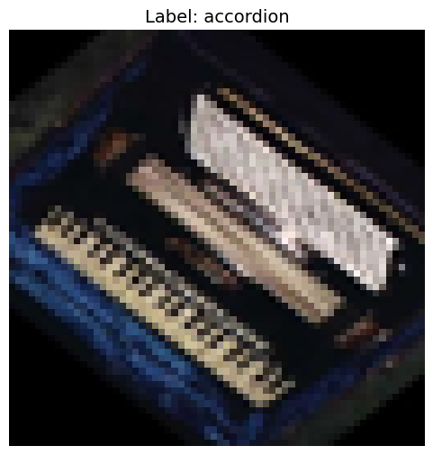

```python
import matplotlib.pyplot as plt

def plot_image(image, one_hot_label, lb, figsize=(6, 6)):
    # Rescale the image data to 0-1 range for displaying
    image_rescaled = (image - image.min()) / (image.max() - image.min())

    # Inverse transform the one-hot encoded label to get the original label
    label = lb.inverse_transform(np.array([one_hot_label]))[0]

    plt.figure(figsize=figsize)
    plt.imshow(image_rescaled)
    plt.title(f"Label: {label}", fontsize=14)
    plt.axis('off')
    plt.show()

example_image_index = 1
plot_image(images[example_image_index], one_hot_labels[example_image_index], lb)
```

#### 2) Standardize the images (5%)

**Note:** Some of these operations can be performed during step 1). If that's the case, don't do them again here.

Unify the images:

- Number and sequence of channels (RGB) if needed
- Images shape (e.g. $32 \times 32 \times 3$) - including channel convention (*channels_last* suggested)
- Standardization of pixel values, e.g. ($\frac{x - \mu}{\sigma}$) - calculate $\mu$ and $\sigma$ for the whole dataset, separately for each channel

**Note:** Standardization should be done based on $\mu$ and $\sigma$ calculated only on the train set to prevent information from leaking from the test set to the training phase. For this reason, it is worth splitting the dataset first and then standardizing the images.

**Step verification:**

Check what the image you selected in step 1) looks like now.

## Image Standardization

### Objective

Standardization of images is a critical preprocessing step in machine learning and deep learning. This step involves transforming the pixel values of the images so that they have a standard format, making it easier for the model to learn and understand the data.

### Standardization Process

1. **Channel Uniformity:**
   - Ensure that all images have the same number and sequence of color channels, typically RGB (Red, Green, Blue).
   - This is essential because different channel orders or numbers can significantly affect the model's learning process.
2. **Image Resizing:**
   - Resize all images to a uniform shape (e.g., $32 \times 32 \times 3$). The channel convention suggested is *channels_last*.
   - Uniformity in image size is crucial as it allows the model to process them in batches efficiently and apply the same filters across all images.
3. **Pixel Value Standardization:**
   - Standardize pixel values using the formula: $\frac{x - \mu}{\sigma}$.
   - Here, $\mu$ and $\sigma$ represent the mean and standard deviation of the pixel values in the training dataset, calculated separately for each channel.
   - Standardizing pixel values helps in normalizing the data range, improving the convergence speed of the model during training.

### Implementation

- The function `standardize_images` takes the images and calculates their mean and standard deviation.
- It then applies the standardization formula to each image.
- It's crucial to calculate $\mu$ and $\sigma$ only on the training dataset to prevent information leakage from the test set.

### Step Verification

- To verify the effectiveness of the standardization, we use the `plot_image` function on an example image from step 1.
- This helps us visualize the changes and ensure that the standardization process is correctly implemented.

### Conclusion

Standardizing images is a foundational step that can significantly impact the performance of a deep learning model. Properly standardized images provide a consistent and normalized input format, which facilitates more efficient and effective learning.

```
[139.8986303  135.4609143  128.77037023] [78.6191461  77.17614437 80.46164054]
```

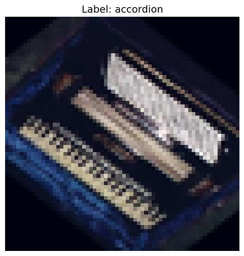

```python
def standardize_images(images, mean, std):
    images_standardized = (images - mean) / std
    return images_standardized

mean, std = np.mean(images, axis=(0, 1, 2)), np.std(images, axis=(0, 1, 2))
print(mean, std)
std_img = standardize_images(images[example_image_index], mean, std)
plot_image(std_img, one_hot_labels[example_image_index], lb)
```

#### 3) Divide the collection into Train and Test set (5%)

- Reduce the number of classes - filter the collection and leave images from ~15-25 classes, select those classes that have the largest number of examples. Make sure your collection is balanced (roughly the same number of samples for each class). You can do this by discarding classes that cause imbalance, or you can reduce the number of samples in larger classes.
- Randomly split the set into train (70%) and test (30%) set - X_train, X_test (images) and y_train, y_test (labels). (**hint:** check *sklearn.model_selection.train_test_split*)
- Make sure that the proportions of each class in both sets are more or less the same as in the whole set (**hint:** *stratify* parameter in *train_test_split*)
- Change labels in y vectors to one-hot encoding
- Ensure image and label collections are in the form of numpy.array

**Note:** Once you have selected a subset of classes, check what images contain those classes - are they appropriate for the classification problem? "BACKGROUND_Google" is probably not the best choice :)

**Step verification:**

- Check the shape of the X_train, X_test (images) and the y_train, y_test (labels)
- Check some sample images to see if the label is correct
- Check how many samples from each class are in particular subsets (train and test) and whether the proportions are the same in both subsets

## Filtering and Balancing Dataset Classes

### Purpose

To create a balanced and representative dataset for our classification model, it is crucial to filter out irrelevant classes and balance the number of samples across the selected classes. This step is essential to prevent class imbalance, which can lead to biased models.

### Implementation

- **Selection of Classes:**
  - We start by excluding certain classes (e.g., "BACKGROUND_Google") that are not relevant for our classification problem.
  - We then identify the top `num_classes` classes with the most samples, ensuring that our model has enough data for each class.
- **Balancing Classes:**
  - To balance the dataset, we limit the number of samples per class to the count of the least represented class in our selection.
  - This is achieved by randomly selecting a uniform number of samples from each class.
- **LabelBinarizer for New Classes:**
  - A new `LabelBinarizer` instance is created and fitted to the selected classes for one-hot encoding.

### Function: `filter_and_balance_classes`

This function takes the images and labels as input and performs the above steps to filter and balance the classes. It returns the filtered and balanced images, one-hot encoded labels, and the updated `LabelBinarizer` object.

### Conclusion

Balancing and filtering the dataset is a critical step in preparing our data for training a robust and unbiased classification model.

```python
def filter_and_balance_classes(images, labels, num_classes, exclude_classes=["BACKGROUND_Google"]):

    unique_classes = np.unique(labels)
    # Remove specified exclude_classes
    for exclude_class in exclude_classes:
        if exclude_class in unique_classes:
            unique_classes = np.delete(unique_classes, np.where(unique_classes == exclude_class))

    # Select the top `num_classes` classes based on the number of samples
    class_counts = {label: sum(labels == label) for label in unique_classes}
    sorted_classes = sorted(class_counts, key=class_counts.get, reverse=True)[:num_classes]

    # Filter and balance images and labels
    filtered_images, filtered_labels = [], []
    min_samples = min([class_counts[cls] for cls in sorted_classes])

    for cls in sorted_classes:
        cls_indices = np.where(labels == cls)[0]
        np.random.shuffle(cls_indices)
        selected_indices = cls_indices[:min_samples]

        for idx in selected_indices:
            filtered_images.append(images[idx])
            filtered_labels.append(labels[idx])

    # Create new LabelBinarizer for the filtered classes
    lb = LabelBinarizer()
    lb.fit(sorted_classes)
    filtered_one_hot_labels = lb.transform(filtered_labels)

    return np.array(filtered_images), filtered_one_hot_labels, lb
```

## Verifying Dataset Distribution and Samples

### Objective

After splitting the dataset into training and test sets, it's important to verify the distribution of classes and visualize some sample images to ensure the integrity and balance of our dataset.

### Verification Steps

1. **Display Dataset Shapes:**
   - We check the shapes of `X_train`, `X_test`, `y_train`, and `y_test` to confirm the successful split of our dataset.
2. **Check Class Distribution:**
   - We verify the class distribution in both the training and test sets to ensure that it's consistent with the overall dataset distribution. This step helps confirm that our split is representative of the original dataset.
3. **Visual Inspection of Samples**
   - By randomly displaying a few sample images from both sets, we visually inspect if the images correspond to their labels. This helps in detecting any potential issues in the dataset.

### Function: `verify_dataset`

This function takes the training and test sets, along with the LabelBinarizer object, and performs the above verification steps. It ensures that the dataset is correctly split and the class distribution is maintained.

### Conclusion

Verifying the dataset after splitting is a crucial step to ensure the quality and reliability of the training and test sets. It helps in maintaining the consistency and balance necessary for training an effective model.

```python
def verify_dataset(X_train, y_train, X_test, y_test, lb, num_samples=2):

    def display_sample_images(X, y, lb):
        sample_indices = np.random.choice(range(len(X)), num_samples, replace=False)
        for idx in sample_indices:
            plot_image(X[idx], y[idx], lb)

    def verify_class_distribution(y):
        class_distribution = np.sum(y, axis=0)
        print("Class distribution:", class_distribution)

    print("Shapes - X_train:", X_train.shape, "X_test:", X_test.shape, "y_train:", y_train.shape, "y_test:", y_test.shape)

    print("\nClass distribution in the training set:")
    verify_class_distribution(y_train)

    print("\nClass distribution in the test set:")
    verify_class_distribution(y_test)

    print("\nSample images from the training set:")
    display_sample_images(X_train, y_train, lb)

    print("\nSample images from the test set:")
    display_sample_images(X_test, y_test, lb)
```

## Preparing Train and Test Sets

### Goal

The objective is to split the dataset into training and test sets while ensuring that the class distribution remains consistent across these subsets. This is vital for training a model that generalizes well.

### Process

1. **Dataset Filtering and Balancing:**
   - We use the `filter_and_balance_classes` function to select the desired number of classes and balance the dataset.
2. **Train-Test Split:**
   - The dataset is then split into training (70%) and test (30%) sets using `train_test_split` from `sklearn.model_selection`.
   - The `stratify` parameter ensures that the class distribution is similar in both the training and test sets.
3. **Standardization:**
   - We calculate the mean and standard deviation of the training set for standardization.
   - The training and test sets are then standardized using these values.
4. **Verification:**
   - Optionally, the `verify_dataset` function can be called to check the final split and distribution.

### Function: `prepare_train_test_sets`

This function encompasses the entire process of preparing the training and test sets. It returns the standardized image sets and their corresponding one-hot encoded labels.

### Conclusion

Properly preparing the training and test sets is a cornerstone for any machine learning project. It ensures that the model is trained and evaluated on data that is representative and balanced, leading to more robust and reliable performance.

```
Shapes - X_train: (1190, 64, 64, 3) X_test: (510, 64, 64, 3) y_train: (1190, 20) y_test: (510, 20)

Class distribution in the training set:
Class distribution: [59 60 60 60 60 59 59 59 60 59 59 60 59 59 60 59 60 59 60 60]

Class distribution in the test set:
Class distribution: [26 25 25 25 25 26 26 26 25 26 26 25 26 26 25 26 25 26 25 25]

Sample images from the training set:
```

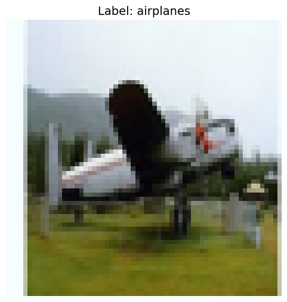

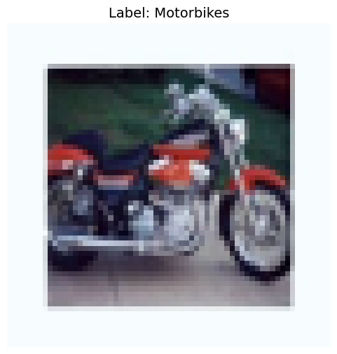

```
Sample images from the test set:
```

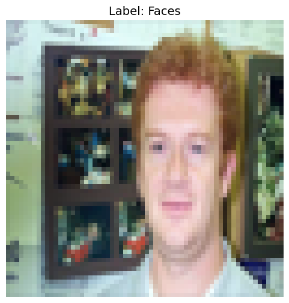

[figure not shown]

```python
from sklearn.model_selection import train_test_split

def prepare_train_test_sets(images, labels, num_classes=20, test_size=0.3, random_state=None, verify=False):

    # Filter and balance the dataset
    X, y, lb = filter_and_balance_classes(images, labels, num_classes)

    # Split into training and test sets
    X_train, X_test, y_train, y_test = train_test_split(
        X, y, test_size=test_size, stratify=y, random_state=random_state)

    # Calculate mean and std of the training set for each channel
    train_mean = np.mean(X_train, axis=(0, 1, 2))
    train_std = np.std(X_train, axis=(0, 1, 2))

    # Standardize the training and testing sets
    X_train_std = standardize_images(X_train, train_mean, train_std)
    X_test_std = standardize_images(X_test, train_mean, train_std)

    if verify:
        verify_dataset(X_train_std, y_train, X_test_std, y_test, lb)

    return X_train_std, X_test_std, y_train, y_test, lb

X_train_std, X_test_std, y_train, y_test, lb = prepare_train_test_sets(images, labels, random_state=42, verify=True)
```

**4) Define the model (5%)**

**Note:** you should probably try different settings and choose the *best* one. Below you will find a proposed definition of a network:

- Activation functions - *ReLU*
- At least 3 *Convolutional blocks* - (Conv2D, Activation, BatchNormalization, Dropout, MaxPooling2D)
  - Conv2D - *kernel=(3,3)*, *padding='same'*
  - MaxPooling2D - *pool_size=(2,2)*
- Flatten layer
- At least 2 layers Fully-Connected (Dense)
- Output layer - Dense with number_of_classes outputs (remember to use softmax)

**Note:** You can add *Activation* as a separate layer or as *activation='relu'* parameter in Conv2D

**Step verification:**

Compile the model with *'adam'* optimizer, the Categorical Crossentropy as the loss function, and measure the accuracy value.

## Defining the CNN Model

### Purpose

Designing an effective CNN architecture is key to achieving high performance in image classification tasks. This step involves defining the structure of the neural network, including the layers and their specific configurations.

### Model Architecture

- **Convolutional Blocks:**
  - We use multiple convolutional blocks, each comprising Conv2D, Activation (ReLU), BatchNormalization, Dropout, and MaxPooling2D (or AveragePooling2D, depending on the configuration).
  - Conv2D layers with a kernel size of `(3,3)` and `padding='same'` are used to extract features from the images.
- **Global Pooling (Optional):**
  - Global pooling can be used instead of Flatten layer to reduce the dimensions while retaining important information.
- **Flatten Layer:**
  - A Flatten layer is used to transform the 2D feature maps into a 1D vector, essential before passing data to the fully connected layers.
- **Fully Connected Layers:**
  - At least two Dense layers are included, with the first having a customizable number of neurons (default is 128).
- **Output Layer:**
  - The final Dense layer has a number of neurons equal to the number of classes and uses the softmax activation function for multi-class classification.

### Customization Options

- **Dropout Rate & Batch Normalization:**
  - Dropout and BatchNormalization are configurable for regularization and to reduce overfitting.
- **Pooling Type & Regularization:**
  - The model allows for selecting between MaxPooling and AveragePooling, and also the application of L1, L2, or combined regularization.

### Function: `create_cnn_model`

The `create_cnn_model` function encapsulates the model definition, allowing for customization of various aspects like the number of convolutional blocks, type of pooling, and dropout rate, among others.

### Model Compilation

- The model is compiled with the Adam optimizer, categorical crossentropy as the loss function, and accuracy as the metric.
- This setup is commonly used for multi-class image classification tasks.

### Conclusion

The flexibility of the CNN model definition allows for experimenting with different architectures to find the best configuration for the specific classification problem at hand.

## Importance of Each Component in the CNN Model

### Convolutional Layers

- **Feature Extraction:**
  - Conv2D layers with ReLU activation function are crucial for feature extraction in images. They detect patterns like edges, textures, and more complex structures as we add more layers.

### Batch Normalization

- **Stabilizing Training:**
  - Batch normalization standardizes the inputs to a layer, which can speed up training and reduce the sensitivity to network initialization.

### Dropout

- **Preventing Overfitting:**
  - Dropout randomly deactivates a fraction of neurons during training, which helps prevent overfitting by ensuring that the network doesn't rely too heavily on a small number of neurons.

### Pooling Layers

- **Dimensionality Reduction:**
  - MaxPooling (or AveragePooling) reduces the spatial dimensions (height and width) of the input volume, which decreases the number of parameters and computation in the network.

### Global Pooling

- **Alternative to Flatten:**
  - Global pooling layers, like GlobalMaxPooling or GlobalAveragePooling, can be used as an alternative to Flatten for reducing dimensions while retaining important spatial hierarchies.

### Dense Layers and Regularization

- **Classification Decisions:**
  - Dense layers make classification decisions based on the features extracted by the convolutional layers. Regularization (like L1 or L2) is applied here to further prevent overfitting.

### Output Layer with Softmax

- **Predicting Probabilities:**
  - The final Dense layer with softmax activation function is used for predicting the probability distribution over the classes.

## Customizing and Compiling the CNN Model

### Customization Flexibility

- **Adjustable Parameters:**
  - The `create_cnn_model` function allows for adjusting key parameters like the number of convolutional blocks, dropout rate, number of neurons in the dense layers, and the type of regularization.

### Compilation Settings

- **Optimizer:**
  - The model uses the Adam optimizer, known for its efficiency and effectiveness in various types of neural networks, including CNNs.
- **Loss Function:**
  - Categorical crossentropy is used as the loss function, which is standard for multi-class classification problems.
- **Metrics:**
  - Accuracy is chosen as the metric to provide a clear and interpretable measure of the model's performance.

### Step Verification

- **Model Summary:**
  - Upon creating the model, we can call `model.summary()` to verify the structure and ensure all components are correctly implemented.
- **Trial Runs:**
  - Before finalizing the model, conducting trial runs with different configurations can help in identifying the most effective architecture for the specific dataset.

### Practical Implications

- **Experimentation:**
  - Experimenting with different numbers of layers, neurons, and dropout rates is essential to find the optimal balance between model complexity and performance.
- **Model Efficiency:**
  - Adjusting these parameters can also impact the model's training efficiency and ability to generalize to new data.

### Conclusion

Customizing and compiling the CNN model with the right combination of layers, activation functions, and regularization techniques is crucial for achieving high accuracy in image classification tasks. The flexibility provided by the create_cnn_model function allows for extensive experimentation to find the best model architecture for the given dataset.

```python
import tensorflow as tf
from tensorflow.keras import layers, models

def create_cnn_model(input_shape,
                     num_classes,
                     dropout_rate=0.4,
                     dense_neurons=128,
                     use_batch_norm=True,
                     activation='relu',
                     pooling='max',
                     use_global_pooling=False,
                     use_regularizer=None,
                     conv_blocks=4,
                     neurons_per_block=[32, 32, 64, 16],
                     kernel_sizes_per_block=[(3, 3), (3, 3), (3, 3), (3, 3)],
                     custom_loss=None):

    model = models.Sequential()

    for i in range(conv_blocks):
        neurons = neurons_per_block[i] if i < len(neurons_per_block) else neurons_per_block[-1]
        kernel_size = kernel_sizes_per_block[i] if i < len(kernel_sizes_per_block) else kernel_sizes_per_block[-1]

        if i == 0:
            model.add(layers.Conv2D(neurons, kernel_size, padding='same', activation=activation, input_shape=input_shape))
        else:
            model.add(layers.Conv2D(neurons, kernel_size, padding='same', activation=activation))

        if use_batch_norm:
            model.add(layers.BatchNormalization())

        if not use_global_pooling:
            if pooling == 'max':
                model.add(layers.MaxPooling2D((2, 2)))
            elif pooling == 'average':
                model.add(layers.AveragePooling2D((2, 2)))

        if dropout_rate:
            model.add(layers.Dropout(dropout_rate))

    # Global Pooling
    if use_global_pooling:
        if pooling == 'max':
            model.add(layers.GlobalMaxPooling2D())
        elif pooling == 'average':
            model.add(layers.GlobalAveragePooling2D())
    else:
        model.add(layers.Flatten())

    # Regularization
    regularizer = None
    if use_regularizer == 'l1':
        regularizer = tf.keras.regularizers.l1(0.01)
    elif use_regularizer == 'l2':
        regularizer = tf.keras.regularizers.l2(0.01)
    elif use_regularizer == 'l1_l2':
        regularizer = tf.keras.regularizers.l1_l2(l1=0.01, l2=0.01)

    model.add(layers.Dense(dense_neurons, activation=activation, kernel_regularizer=regularizer))
    model.add(layers.Dropout(dropout_rate))
    model.add(layers.Dense(num_classes, activation='softmax'))

    loss = custom_loss if custom_loss else 'categorical_crossentropy'
    model.compile(optimizer='adam', loss=loss, metrics=['accuracy'])

    return model
```

**5) Train the model (5%)**

Suggested hyperparameters:

- batch_size = 32
- epochs = 250 (or whatever you think is appropriate; to avoid wasting time, start by checking if everything works on several epochs)
- Monitor the value of measures for the test set
- Add EarlyStopping - stop training when there is no improvement in accuracy for the test set within 5 consecutive epochs (you can first test the behavior for patience = 1)

**Step verification:**

After completing the learning process, show:

- Learning curves for loss_function and accuracy, changing over the epochs on train and test set
- Confusion matrix and calculate precision and recall for each class for test set
- Show few images from the test set, display the probabilities of assigning them to each class (at least two examples: one image example that was classified correctly and one which was classified incorrectly)

**Note:** Functions to display learning curves and confusion matrices based on the model will be useful in the Part 2.

## Training the CNN Model

### Objective

The aim is to train the CNN model on the dataset to learn to classify images into their respective classes. This step involves setting appropriate hyperparameters and monitoring the training process.

### Function: `train_model`

The `train_model` function encapsulates the training process, including model compilation, fitting, and the application of callbacks like early stopping.

### Monitoring and Timing

- **Verbose Option:**
  - The function has a `verbose` parameter to control the output of training progress.
- **Training Time Measurement:**
  - The function also measures the total time taken for training, providing insights into the efficiency of the model.

### Conclusion

Training the model with these settings and monitoring tools ensures that we effectively learn from the training data while avoiding overfitting, leading to a model that generalizes well on unseen data.

```python
from tensorflow.keras.callbacks import EarlyStopping
import time

def train_model(model, X_train, y_train, X_test, y_test, batch_size=32, epochs=250, verbose=False):
    # Compile the model (recompile to avoid issues)
    model.compile(optimizer='adam', loss='categorical_crossentropy', metrics=['accuracy'])

    # Early Stopping Callback
    early_stopping = EarlyStopping(monitor='val_accuracy', patience=10, restore_best_weights=True)

    start_time = time.time()
    # Train the model without data augmentation
    history = model.fit(
        X_train, y_train,
        batch_size=batch_size,
        epochs=epochs,
        validation_data=(X_test, y_test),
        callbacks=[early_stopping],
        verbose=1 if verbose else 0)  # Set verbose level based on the argument

    end_time = time.time()
    training_time = end_time - start_time
    num_params = model.count_params()

    return history.history, training_time, num_params
```

## Model Evaluation and Visualization

### Purpose

After training, it is crucial to evaluate the model's performance on the test set and visualize key metrics to understand the model's strengths and weaknesses.

### Evaluation Metrics

- **Accuracy and Loss Curves:**
  - Plotting the training and validation accuracy and loss over epochs helps in assessing the learning process and identifying overfitting.
- **Confusion Matrix:**
  - A confusion matrix is used to visualize the model's performance across different classes, showing the counts of true positives, false positives, true negatives, and false negatives.

### Function: `plot_and_evaluate_model`

This function takes the trained model, its history, and the test dataset to perform the following tasks:

1. **Plot Learning Curves:**
   - Displays the training and validation accuracy and loss.
2. **Generate and Plot Confusion Matrix:**
   - Predicts classes for the test set.
   - Generates a confusion matrix and visualizes it using a heatmap.
3. **Classification Report:**
   - Generates a detailed classification report including precision, recall, and F1-score for each class.

### Conclusion

Visualizing these metrics is essential for interpreting the model's performance and making informed decisions on potential improvements or adjustments needed in the model architecture or training process.

```python
import matplotlib.pyplot as plt
import seaborn as sns
from sklearn.metrics import confusion_matrix, classification_report
import pandas as pd
import numpy as np

def plot_and_evaluate_model(model, history, X_test, y_test, lb):

    # Plot learning curves
    acc = history['accuracy']
    val_acc = history['val_accuracy']
    loss = history['loss']
    val_loss = history['val_loss']

    plt.figure(figsize=(12, 4))
    plt.subplot(1, 2, 1)
    plt.plot(acc, label='Training Accuracy')
    plt.plot(val_acc, label='Validation Accuracy')
    plt.title('Training and Validation Accuracy')
    plt.legend()

    plt.subplot(1, 2, 2)
    plt.plot(loss, label='Training Loss')
    plt.plot(val_loss, label='Validation Loss')
    plt.title('Training and Validation Loss')
    plt.legend()
    plt.show()

    # Evaluate the model
    y_pred = model.predict(X_test)
    y_pred_classes = np.argmax(y_pred, axis=1)
    y_true = np.argmax(y_test, axis=1)

    # Confusion Matrix and Classification Report
    cm = confusion_matrix(y_true, y_pred_classes)
    plt.figure(figsize=(10, 8))
    sns.heatmap(cm, annot=True, fmt='d')
    plt.title('Confusion Matrix')
    plt.ylabel('True label')
    plt.xlabel('Predicted label')
    plt.show()
    print(cm)

    # Display classification report
    report = classification_report(y_true, y_pred_classes, target_names=lb.classes_, output_dict=True)
    df_report = pd.DataFrame(report).transpose()
    return df_report
```

**6) Save the model to disk (5%)**

- Prepare 2 functions - for saving the model and for loading the model
- Model structure should be saved as JSON file, model parameters in HDF5 file

**Step verification:**

Checking the operation of both functions by:

- Save the model
- Load the model
- Make predictions on the loaded model for the test set
- Display the confusion matrix for the test set and compare it with the matrix obtained in the previous step to see if saving and loading worked properly

## Saving the Model and Training Data

### Objective

The purpose of this step is to save the trained model and its associated data to disk. This allows for the model to be reused or shared without the need to retrain it.

### Implementation

- **Model Structure and Weights:**
  - The model's structure is saved as a JSON file, and its weights are saved in an HDF5 file. This separation allows for easy model architecture sharing and modification.
- **Training History and Parameters:**
  - Along with the model, the training history and parameters like training time and the number of parameters are also saved. This data is crucial for analyzing the model's training process and performance.
- **Test Set and Label Encoder:**
  - The test dataset and the LabelBinarizer (`lb`) object are saved using Python's `pickle` module. Saving the test set and `lb` ensures consistency when reloading the model for further evaluation or predictions.

### Function: `save_model_and_data`

This function encapsulates the entire process of saving the model, training history, and associated data. It creates the necessary directory if it doesn't exist and then saves each component in the specified path.

### Conclusion

Saving the model and its data is a best practice in machine learning, allowing for efficient reuse and sharing of trained models. It also serves as a backup to recover the model state in case of any disruptions.

```python
import json
import pickle

def save_model_and_data(model, history, training_time, num_params, path_name, model_name, X_test, y_test, lb):
    # Create directory if it doesn't exist
    if not os.path.exists(path_name):
        os.makedirs(path_name)

    # Save model and weights
    model_json = model.to_json()
    with open(f"{path_name}/{model_name}.json", "w") as json_file:
        json_file.write(model_json)
    model.save_weights(f"{path_name}/{model_name}.h5")

    # Save training history and time
    history_with_time_and_params = history
    history_with_time_and_params['training_time'] = training_time
    history_with_time_and_params['num_params'] = num_params

    with open(f"{path_name}/{model_name}_history.json", "w") as history_file:
        json.dump(history, history_file)

    print(f"Model {model_name} saved successfully.")

    with open(f"{path_name}/{model_name}_data.pkl", "wb") as data_file:
        pickle.dump({'X_test': X_test, 'y_test': y_test, 'lb': lb}, data_file)

    print(f"Data for {model_name} saved successfully.")
```

## Loading the Model and Training Data

### Purpose

The ability to load a previously saved model and its training data is essential for model evaluation, further training, and deployment.

### Process

- **Loading Data:**
  - Test set and `LabelBinarizer` (`lb`) are loaded from the saved pickle file.
- **Model Structure and Weights:**
  - The model's structure is loaded from the JSON file, and the weights are loaded from the HDF5 file.
- **Compiling the Model:**
  - After loading, the model is compiled with the same configuration (optimizer, loss function, and metrics) used during training.
- **Training History:**
  - The training history is loaded from its saved JSON file, allowing for further analysis of the model's training process.

### Function: `load_model_and_history`

This function handles the loading of the model, its training history, and the test data. It ensures that the loaded model is ready for immediate use or further evaluation.

### Conclusion

Loading the model and associated data is a crucial step for continuous development, evaluation, and deployment of machine learning models. It provides flexibility and efficiency, especially in scenarios requiring model updates or performance reviews.

```python
def load_model_and_history(path_name, model_name):

    with open(f"{path_name}/{model_name}_data.pkl", "rb") as data_file:
        data = pickle.load(data_file)
    X_test = data['X_test']
    y_test = data['y_test']
    lb = data['lb']

    with open(f"{path_name}/{model_name}.json", "r") as json_file:
        loaded_model_json = json_file.read()
    loaded_model = models.model_from_json(loaded_model_json)
    loaded_model.load_weights(f"{path_name}/{model_name}.h5")
    loaded_model.compile(optimizer='adam', loss='categorical_crossentropy', metrics=['accuracy'])

    with open(f"{path_name}/{model_name}_history.json", "r") as history_file:
        loaded_history = json.load(history_file)

    return loaded_model, loaded_history, X_test, y_test, lb
```

## Creating and Training the Model with Persistence

### Overview

This step involves either training a new model or loading an existing one from disk, providing flexibility in managing the training process and model updates.

### Process

- **Check for Existing Model:**
  - The function first checks if the model and its data already exist in the specified path.
- **Load or Train:**
  - If the model exists, it is loaded along with its training history and test data.
  - If not, a new model is created and trained using the provided dataset.
- **Saving New Model:**
  - In case of training a new model, it is saved along with its training data and history upon completion.

### Function: `create_and_train_model`

This function offers a streamlined approach to model management. It automatically decides whether to train a new model or load an existing one based on the presence of saved model files.

### Conclusion

The ability to create, train, and save models, or to load pre-trained models, is a critical aspect of efficient machine learning workflows. It allows for seamless model development and deployment, saving time and resources.

```python
def create_and_train_model(model, X_train, y_train, X_test, y_test, lb, input_shape, num_classes, path_name, model_name, epochs=250, dropout_rate=0.4, activation='relu', use_regularizer=None, use_batch_norm=True, pooling='max', use_global_pooling=False, verbose=False):
    if os.path.exists(f"{path_name}/{model_name}.json") and os.path.exists(f"{path_name}/{model_name}.h5"):
        print("Loading existing model...")
        model, history, X_test, y_test, lb = load_model_and_history(path_name, model_name)
        training_time = history['training_time'] if 'training_time' in history else None
        num_params = history['num_params'] if 'num_params' in history else None
    else:
        print("Training new model...")
        model = create_cnn_model(input_shape=input_shape, num_classes=num_classes, dropout_rate=dropout_rate, activation=activation, use_regularizer=use_regularizer, use_batch_norm=use_batch_norm, pooling=pooling, use_global_pooling=use_global_pooling)
        history, training_time, num_params = train_model(model, X_train, y_train, X_test, y_test, epochs=epochs, verbose=verbose)
        save_model_and_data(model, history, training_time, num_params, path_name, model_name, X_test, y_test, lb)
    return model, history, training_time, num_params, X_test, y_test, lb
```

## Model Initialization and Training Workflow

### Goal

The aim here is to initialize the CNN model with appropriate input shape and number of classes, and then proceed to either train it or load a pre-trained model.

### Steps

1. **Model Initialization:**
   - The model is initialized with the specified input shape and number of classes.
2. **Model Summary:**
   - A summary of the model is displayed to verify its architecture and parameter count.
3. **Training or Loading:**
   - The `create_and_train_model` function is called with the necessary parameters to handle model training or loading.

### Conclusion

The process of initializing and training the model, or loading a pre-trained model, is streamlined for efficiency and effectiveness. This approach ensures that the model is correctly configured for the task at hand, and allows for flexibility in model development and evaluation. By providing a clear workflow, it facilitates a more organized and manageable machine learning project, enhancing the overall development experience.

```python
input_shape = X_train_std.shape[1:]
num_classes = y_train.shape[1]
print("Input shape:", input_shape, "Num classes:", num_classes)
model = create_cnn_model(
    input_shape=input_shape,
    num_classes=num_classes,
)
model.summary()
model, history, training_time, num_params, X_test, y_test, lb = create_and_train_model(model, X_train_std, y_train, X_test_std, y_test, lb, input_shape, num_classes, "models", "model_1", epochs=250)
```

[output not shown]

[output cut: 29 more lines]

```

 flatten_3 (Flatten)         (None, 256)               0

 dense_6 (Dense)             (None, 128)               32896

 dropout_19 (Dropout)        (None, 128)               0

 dense_7 (Dense)             (None, 20)                2580

=================================================================
Total params: 73924 (288.77 KB)
Trainable params: 73636 (287.64 KB)
Non-trainable params: 288 (1.12 KB)
_________________________________________________________________
Loading existing model...
```

## Model Summary and Analysis

### Input Shape and Number of Classes

- **Input Shape:** `(64, 64, 3)` - This indicates that our model will be processing images of size 64x64 pixels with 3 color channels (RGB).
- **Number of Classes:** `20` - The model will classify images into one of 20 different categories.

### Model Architecture Overview

1. **Convolutional Layers (Conv2D):**
   - Four convolutional layers are used, with varying numbers of filters (32, 32, 64, and 16).
   - These layers are responsible for extracting features from the input images.
2. **Batch Normalization:**
   - Each convolutional layer is followed by a batch normalization layer, helping in stabilizing and speeding up the training process.
3. **Pooling Layers (MaxPooling2D):**
   - Max pooling layers are used after each convolutional layer to reduce the spatial dimensions of the feature maps, thereby reducing the number of parameters and computation in the network.
4. **Dropout Layers:**
   - Dropout layers follow each pooling layer, with a role in reducing overfitting by randomly setting a fraction of input units to zero during training.
5. **Flatten Layer:**
   - The Flatten layer converts the 2D feature maps into a 1D feature vector, necessary before passing data to the fully connected layers.
6. **Dense Layers:**
   - A fully connected layer with 128 neurons (Dense) is used, followed by another Dense layer with 20 neurons, corresponding to the number of classes. The last layer uses the softmax activation function for multi-class classification.

### Model Parameters

- **Total Parameters:** `73,924` (Approx. 288.77 KB)
  - This is the total number of trainable and non-trainable parameters in the model.
- **Trainable Parameters:** `73,636` (Approx. 287.64 KB)
- **Non-Trainable Parameters:** `288` (Approx. 1.12 KB)

### Conclusion

The defined CNN model is a relatively compact yet powerful architecture for image classification. It utilizes a series of convolutional, normalization, pooling, and dropout layers, followed by dense layers for classification. This architecture is designed to effectively learn from the image data while managing computational complexity and avoiding overfitting.

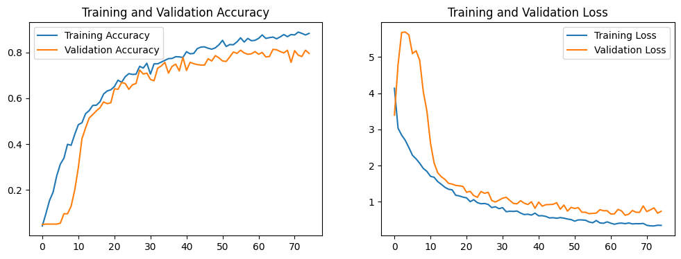

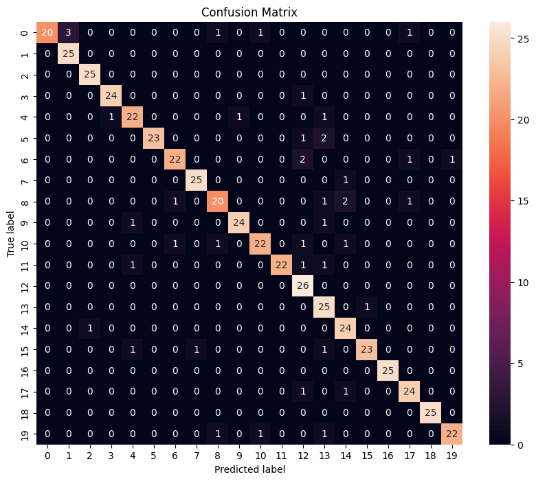

```
[[20  3  0  0  0  0  0  0  1  0  1  0  0  0  0  0  0  1  0  0]
 [ 0 25  0  0  0  0  0  0  0  0  0  0  0  0  0  0  0  0  0  0]
 [ 0  0 25  0  0  0  0  0  0  0  0  0  0  0  0  0  0  0  0  0]
 [ 0  0  0 24  0  0  0  0  0  0  0  0  1  0  0  0  0  0  0  0]
 [ 0  0  0  1 22  0  0  0  0  1  0  0  0  1  0  0  0  0  0  0]
 [ 0  0  0  0  0 23  0  0  0  0  0  0  1  2  0  0  0  0  0  0]
 [ 0  0  0  0  0  0 22  0  0  0  0  0  2  0  0  0  0  1  0  1]
 [ 0  0  0  0  0  0  0 25  0  0  0  0  0  0  1  0  0  0  0  0]
 [ 0  0  0  0  0  0  1  0 20  0  0  0  0  1  2  0  0  1  0  0]
 [ 0  0  0  0  1  0  0  0  0 24  0  0  0  1  0  0  0  0  0  0]
 [ 0  0  0  0  0  0  1  0  1  0 22  0  1  0  1  0  0  0  0  0]
 [ 0  0  0  0  1  0  0  0  0  0  0 22  1  1  0  0  0  0  0  0]
 [ 0  0  0  0  0  0  0  0  0  0  0  0 26  0  0  0  0  0  0  0]
 [ 0  0  0  0  0  0  0  0  0  0  0  0  0 25  0  1  0  0  0  0]
 [ 0  0  1  0  0  0  0  0  0  0  0  0  0  0 24  0  0  0  0  0]
 [ 0  0  0  0  1  0  0  1  0  0  0  0  0  1  0 23  0  0  0  0]
 [ 0  0  0  0  0  0  0  0  0  0  0  0  0  0  0  0 25  0  0  0]
 [ 0  0  0  0  0  0  0  0  0  0  0  0  1  0  1  0  0 24  0  0]
 [ 0  0  0  0  0  0  0  0  0  0  0  0  0  0  0  0  0  0 25  0]
 [ 0  0  0  0  0  0  0  0  1  0  1  0  0  1  0  0  0  0  0 22]]
```

|  | precision | recall | f1-score | support |
| --- | --- | --- | --- | --- |
| Faces | 1.000000 | 0.769231 | 0.869565 | 26.000000 |
| Faces_easy | 0.892857 | 1.000000 | 0.943396 | 25.000000 |
| Leopards | 0.961538 | 1.000000 | 0.980392 | 25.000000 |
| Motorbikes | 0.960000 | 0.960000 | 0.960000 | 25.000000 |
| airplanes | 0.880000 | 0.880000 | 0.880000 | 25.000000 |
| bonsai | 1.000000 | 0.884615 | 0.938776 | 26.000000 |
| brain | 0.916667 | 0.846154 | 0.880000 | 26.000000 |
| buddha | 0.961538 | 0.961538 | 0.961538 | 26.000000 |
| butterfly | 0.869565 | 0.800000 | 0.833333 | 25.000000 |
| car_side | 0.960000 | 0.923077 | 0.941176 | 26.000000 |
| chandelier | 0.916667 | 0.846154 | 0.880000 | 26.000000 |
| grand_piano | 1.000000 | 0.880000 | 0.936170 | 25.000000 |
| hawksbill | 0.787879 | 1.000000 | 0.881356 | 26.000000 |
| helicopter | 0.757576 | 0.961538 | 0.847458 | 26.000000 |
| kangaroo | 0.827586 | 0.960000 | 0.888889 | 25.000000 |
| ketch | 0.958333 | 0.884615 | 0.920000 | 26.000000 |
| menorah | 1.000000 | 1.000000 | 1.000000 | 25.000000 |
| starfish | 0.888889 | 0.923077 | 0.905660 | 26.000000 |
| trilobite | 1.000000 | 1.000000 | 1.000000 | 25.000000 |
| watch | 0.956522 | 0.880000 | 0.916667 | 25.000000 |
| accuracy | 0.917647 | 0.917647 | 0.917647 | 0.917647 |
| macro avg | 0.924781 | 0.918000 | 0.918219 | 510.000000 |
| weighted avg | 0.924584 | 0.917647 | 0.917912 | 510.000000 |

```python
plot_and_evaluate_model(model, history, X_test_std, y_test, lb)
```

## Analysis of Model Training Performance Metrics

### Training and Validation Loss

- **Trend:** The training loss consistently decreased over epochs, indicating effective learning. The validation loss also generally decreased, although with some fluctuations, suggesting the model's ability to generalize to unseen data.

### Training and Validation Accuracy

- **Progression:** Both training and validation accuracy showed an increasing trend, with training accuracy reaching around 88.4% and validation accuracy peaking near 81%. This demonstrates the model's learning capability and its effectiveness on the test set.

### Conclusion

The decreasing loss and increasing accuracy trends are positive indicators of the model's learning and generalization ability. However, the fluctuations in validation loss and the gap between training and validation accuracy suggest potential overfitting, which could be addressed with further model tuning or data augmentation strategies.

## Confusion Matrix Analysis

### Overview

- **Matrix Representation:** The confusion matrix provides a detailed view of the model's performance, showing the actual versus predicted classifications for each class.

### Conclusion

The confusion matrix is a valuable tool for understanding the model's classification behavior across different categories. It highlights areas where the model performs well and where it struggles, providing guidance for further model refinement and training.

## Class-wise Model Evaluation Metrics

### Observations

- **Variability Across Classes:** The performance metrics varied across different classes, with some classes showing higher precision and others higher recall. This variability suggests room for improvement in class-specific feature learning.

### Conclusion

The class-wise precision, recall, and F1-score provide insights into the model's strengths and weaknesses in classifying different categories. Identifying classes with lower scores can guide targeted improvements in the training process or data representation.

```python
import matplotlib.pyplot as plt
import numpy as np

def show_predictions(model, X_test, y_test, lb, correctly_classified_images=3, incorrectly_classified_images=3, unique=True):
    # Predict classes and probabilities
    predictions = model.predict(X_test)
    predicted_classes = np.argmax(predictions, axis=1)
    true_classes = np.argmax(y_test, axis=1)
    class_labels = lb.classes_

    # Function to plot images
    def plot_images(indices, title, num_of_examples):
        plotted_classes = set()
        count = 0
        for index in indices:
            pred_class = predicted_classes[index]

            # Skip if this class was already plotted and unique is True
            if unique and pred_class in plotted_classes:
                continue
            plotted_classes.add(pred_class)

            image = X_test[index]
            label = true_classes[index]

            # Rescale the image data to 0-1 range for displaying
            image_rescaled = (image - image.min()) / (image.max() - image.min())

            # Plot the image with prediction
            plt.figure(figsize=(5, 5))
            plt.imshow(image_rescaled)
            plt.title(f'{title}\nActual: {class_labels[label]}\nPredicted: {class_labels[pred_class]}')
            plt.axis('off')
            plt.show()

            print(f"Acutal: {class_labels[label]}")
            print(f"Predicted: {class_labels[pred_class]}")

            # Show probabilities
            for idx, prob in enumerate(predictions[index]):
                if prob > 0.000001:
                    print(f"Probability of {class_labels[idx]}: {prob:.6f}")

            count += 1
            if count >= num_of_examples:
                break

    # Separate correctly and incorrectly classified indices
    correct_indices = np.where(predicted_classes == true_classes)[0]
    incorrect_indices = np.where(predicted_classes != true_classes)[0]

    # Correctly classified images with highest certainty
    correct_confidences = predictions[correct_indices, true_classes[correct_indices]]
    correct_confident_indices = np.argsort(-correct_confidences)
    plot_images(correct_indices[correct_confident_indices], "Correctly Classified with Highest Certainty", correctly_classified_images)

    # Incorrectly classified images with lowest certainty
    incorrect_confidences = predictions[incorrect_indices, predicted_classes[incorrect_indices]]
    incorrect_confident_indices = np.argsort(-incorrect_confidences)
    plot_images(incorrect_indices[incorrect_confident_indices], "Incorrectly Classified with Highest Certainty", incorrectly_classified_images)
```

## Visualizing Model Predictions

### Purpose of the Function

The `show_predictions` function is designed to visually display the model's predictions, offering insights into its performance. This function showcases both correctly and incorrectly classified images from the test set.

### Key Features of the Function

1. **Prediction and Classification:**
   - The function predicts classes for the test set and compares these predictions with the true labels to determine correct and incorrect classifications.
2. **Image Display with Predictions:**
   - For each selected image, the function displays the image, its actual label, and the predicted label. This visual representation is crucial for understanding how the model perceives and interprets different images.
3. **Probability Distributions:**
   - Alongside the classification, the function also shows the probabilities assigned to each class for a given image. This helps in understanding the model's certainty in its predictions.
4. **Selection Criteria:**
   - The function allows specifying the number of correctly and incorrectly classified images to display, providing a balanced view of the model's accuracy.
5. **Unique Class Visualization:**
   - An option to display unique classes helps in avoiding repetition and ensures a diverse representation of predictions.

### Usage

- The function is called with the model, test set, labels, and the LabelBinarizer object.
- It provides an intuitive and straightforward way to assess the model's predictive performance on individual examples.

### Conclusion

Visualizing model predictions is an effective method for qualitative assessment. It reveals how the model behaves in real scenarios, highlighting its strengths and pinpointing areas where improvements are needed.

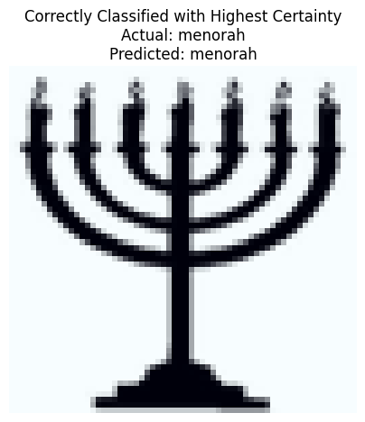

```
Acutal: menorah
Predicted: menorah
Probability of menorah: 1.000000
```

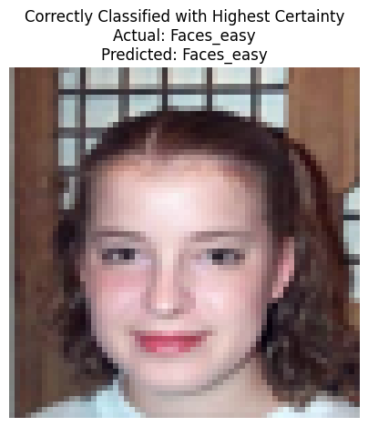

```
Acutal: Faces_easy
Predicted: Faces_easy
Probability of Faces_easy: 1.000000
```

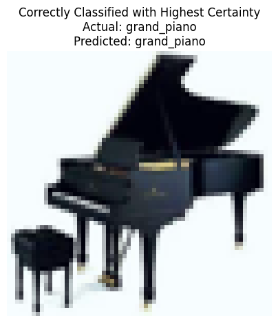

```
Acutal: grand_piano
Predicted: grand_piano
Probability of grand_piano: 1.000000
```

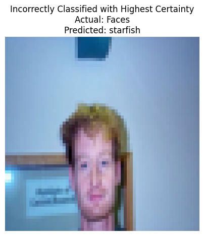

```
Acutal: Faces
Predicted: starfish
Probability of Faces: 0.000471
Probability of Leopards: 0.000004
Probability of bonsai: 0.000001
Probability of brain: 0.000005
Probability of buddha: 0.000091
Probability of butterfly: 0.000100
Probability of chandelier: 0.000029
Probability of grand_piano: 0.000008
Probability of hawksbill: 0.000008
Probability of helicopter: 0.020810
Probability of kangaroo: 0.003474
Probability of ketch: 0.000590
Probability of menorah: 0.000002
Probability of starfish: 0.974406
```

[figure not shown]

```
Acutal: airplanes
Predicted: car_side
Probability of Faces_easy: 0.001777
Probability of Leopards: 0.000001
Probability of Motorbikes: 0.000040
Probability of airplanes: 0.006759
Probability of bonsai: 0.000060
Probability of brain: 0.004436
Probability of buddha: 0.001042
Probability of butterfly: 0.000040
Probability of car_side: 0.950298
Probability of grand_piano: 0.000388
Probability of hawksbill: 0.006560
Probability of helicopter: 0.026717
Probability of kangaroo: 0.001093
Probability of ketch: 0.000043
Probability of menorah: 0.000071
Probability of starfish: 0.000233
Probability of trilobite: 0.000014
Probability of watch: 0.000428
```

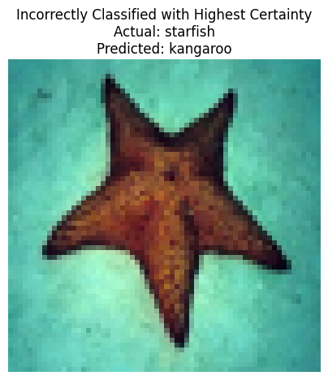

```
Acutal: starfish
Predicted: kangaroo
Probability of Faces: 0.000018
Probability of Leopards: 0.003282
Probability of airplanes: 0.000005
Probability of bonsai: 0.000883
Probability of brain: 0.000005
Probability of buddha: 0.000040
Probability of butterfly: 0.003542
Probability of chandelier: 0.000005
Probability of grand_piano: 0.000188
Probability of hawksbill: 0.002432
Probability of helicopter: 0.002309
Probability of kangaroo: 0.941268
Probability of menorah: 0.000049
Probability of starfish: 0.045973
```

```python
show_predictions(model, X_test_std, y_test, lb)
```

## Analyzing Model Performance through Predictions

### Understanding Probabilities

- The probability distribution for each prediction provides a deeper understanding of the model's decision-making process.
- In cases of incorrect predictions, examining these probabilities can help identify which classes the model confuses the most and why.

### Conclusion

The detailed analysis of individual predictions, both correct and incorrect, along with their probability distributions, offers valuable insights into the model's performance. It helps in identifying specific weaknesses in the model's learning and can guide further improvements or adjustments in the training process.

**7) Summary of the Part 1 - describe your observations (10%)**

Describe your observations on the tasks performed. In general, try to write down everything that you found interesting or worth highlighting. Also mention any modifications you made to the proposed scheme and why you made them.

Supporting questions:

- What kind of modifications have you made? Why? (*Describe, if you made any*)
- What results have you achieved?
- Is the underfitting or overfitting of the model visible? If so, what are your suggestions for solving this problem?
- Which class(es) the model had a trouble with? Which were the easiest for it? Which pair of classes were most often confused with each other? Can you guess why?
- What opportunities do you see for improvement?

**Step verification:**

Use Markdowns to describe your conclusions or put them into the report.

## Summary of Part 1: Image Classifier Implementation

### Overview

In Part 1 of the project, we focused on implementing an image classifier using a Convolutional Neural Network (CNN). This involved steps like data loading, preprocessing, model design, training, and evaluation.

### Modifications and Rationale

- **Early Stopping in Training
  - Implemented EarlyStopping to prevent overfitting and to ensure efficient use of computational resources. The training stops if there's no improvement in validation accuracy over a certain number of epochs.
- **Introduction of Batch Normalization:**
  - Implemented Batch Normalization after each convolutional layer to stabilize and speed up the training process.
- **Hyperparameter Tuning:**
  - Customized the CNN model through extensive hyperparameter tuning, including:
    - `dropout_rate=0.4`: To reduce overfitting by randomly deactivating neurons during training.
    - `dense_neurons=128`: Number of neurons in the fully connected layer, chosen for optimal complexity.
    - `use_batch_norm=True`: Enabled batch normalization.
    - `activation='relu'`: Used ReLU activation for its efficiency and performance in deep networks.
    - `pooling='max'`: Max pooling to reduce spatial dimensions and computational load.
    - `use_global_pooling=False`: Chose not to use global pooling to retain spatial hierarchies.
    - `conv_blocks=4`: Defined four convolutional blocks for adequate feature extraction.
    - `neurons_per_block` and `kernel_sizes_per_block`: Varied the configurations for each convolutional block to capture a wide range of features.

### Opportunities for Improvement

- **Advanced CNN Architectures:**
  - Further experimentation with image preprocessing techniques could improve model performance, especially for classes that are currently underperforming.
- **Hyperparameter Tuning:**
  - More extensive hyperparameter tuning using techniques like grid search or random search could lead to better model performance.
- **Advanced CNN Architectures:**
  - Exploring more advanced CNN architectures, such as ResNet or Inception models, might yield improvements, especially for more complex classification tasks.
- **Feature Engineering:**
  - Investigating feature engineering methods to highlight critical aspects of the images could enhance the model's ability to differentiate between challenging classes.
- **Additional Data Sources::**
  - Incorporating more data, particularly for classes where the model underperforms, could help in better generalization.

### Conclusion

- The first part of this project provided insightful experiences in building and optimizing a CNN for image classification. The high accuracy on the test set, while encouraging, also raises questions about overfitting and data sufficiency, underscoring the need for a balanced approach to model complexity and dataset comprehensiveness. Going forward, the identified opportunities for improvement lay the groundwork for further refining the model and enhancing its performance.

## Part 2 - Experimental comparative analysis

The purpose of the Part 2 is to examine the dependence of the quality of the resulting model on factors such as hyperparameters, model structure, number of training data, number of decision classes, etc. Below is a suggestion of simple tasks - most of them consist of a simple experiment to compare several models that differ in some detail.

### Before you start

- You don't have to complete all of the tasks, you can choose the issues that seem interesting to you. You can also suggest your own ideas for the experiment definition (in this case - consult with the teacher). As mentioned above, each task is worth $20\%$ of the project grade (the value of the last task is doubled, because it requires much more effort). Assuming you completed Part 1 correctly, as you may have already calculated:
  - You should complete at least 1 task *almost* correctly to pass ($40\% + 20\% = 60\% \geq 50\%$)
  - You should complete at least 3 tasks correctly to get the maximum score ($40\% + 3 \cdot 20\% = 100\%$)
  - You can complete more than 3 tasks, then the extra points will ensure that even if one of the tasks is not completely correct, you still have an opportunity to get $100\%$.
- It is possible to combine tasks into one large experiment, because most of the tasks consist of comparing models that differ in one aspect. Thus, instead of conducting individual experiments, you can perform [grid search](https://en.wikipedia.org/wiki/Hyperparameter_optimization#Grid_search) and modify a set of several parameters simultaneously. However, it is important to remember that the conclusions about a given experiment should take into account observations about each of the subtasks (different aspects).
- If you perform several experiments one after another, take into account the conclusions from the previous ones. For example, if in the first experiment you are testing the quality of different models, and in the second you want to check the effect of the dataset size on the results, then in the second task you should use the conclusions of the first experiment (i.e. choose the model that performed better). However, if applying the conclusions of the first study will significantly increase the time of the next experiment, you do not need to apply them to subsequent tasks.
- If you have not already done so, modify the functions in the Part 1 so that they can be used for the following subtasks. You can also rewrite the code and adapt it to the requirements of the tasks.
- Pay attention to the last task - it is more complicated and requires you to find additional information, therefore it is worth $40\%$.

### Collecting experimental data

In addition to implementing the code and running experiments to carry out a given task, you must draw conclusions about the results. In that case, it may be helpful to collect the following information about the compared models:

- The number of network parameters (as a measure of the memory complexity of the model)
- Training time (as a measure of the time complexity of the model)
- Values of the obtained quality measures (loss function, accuracy - maybe other measures should be considered?) for train and test sets in the resulting model
- Values of the loss function and measures in successive epochs (learning curves - can be useful in the context of discussing overfitting, optimization speed and model stability while learning)
- Confusion matrix (mainly in the test set, but maybe the train set matrix will help to better understand the learning process)
- Precision and recall (maybe some other measures?) for decision classes (assessment of classification difficulty for individual classes; comparison of the precision-recall curve between classes and between models)
- Display some examples that were correctly and incorrectly classified by one or more models (example-based explanation)

In general, there are many possibilities to visualize data, to compare models with each other and draw conclusions from it. Only some suggestions are visible above, it is up to you what and how you decide to show in your conclusions and observations.

### Task description

Each of the following tasks assumes the implementation of an appropriate code that will perform a given experiment - and therefore it will probably modify the dataset or model (its structure or hyperparameters). After implementing the experiment, write:

- Which task did you choose?
- What are the differences between the models or data sets you tested?

After obtaining the results for the compared models, datasets or any other aspect, describe your observations and conclusions about the experiment. Observations may in particular concern:

- The overall predictive ability of the model - which model is better, which model is worse, maybe one is better with class X and one with class Y, etc.
- The impact of the changes made on overfitting and underfitting
- Comparison of the duration of learning, the complexity of the model
- Assessment of whether it was profitable to make such a modification (or indicate the best option in your opinion)
- Learning curve shape - in which model the optimization was faster, whether the loss function and accuracy on the test set decreased steadily, were there any deviations, etc.
- Sample images where one model is better than the other - try to answer *why?*
- If something is not working well, write about your assumptions, why it failed and what could be changed. If you want, try the changes you suggest and also describe whether it has brought the desired effect.

In general, it is worth describing everything that you find interesting in the context of the specific task. The description of the conclusions should be included in Markdown(s) (or in the report if you want to prepare one).

### Tasks

#### 1) The impact of the size of the training set on the results - choose one option:

- Compare the results achieved by the same model, e.g. for 15-20 classes that have ~ 80 samples and 15-20 classes that have ~ 30 samples
- You can also use the same classes and reduce the number of samples in the training set (e.g. 50, 40, 30, 20 samples in the training set)
- Another idea - modify the proportion of the division into Train and Test set (e.g. 80-20, 60-40, 40-60, 20-80)

#### 2) The impact of the number of decision classes on the results (e.g. 10, 25, 50, all of the available classes)

#### 3) Compare the models without and with Dropout with different rates (e.g. 0.1, 0.2, 0.5)

#### 4) Compare the models without and with regularization (L1, L2, L1 + L2)

#### 5) Compare the models without and with batch normalization (before or after the activation function)

#### 6) Compare the models for different preprocessing approaches (perform operations separately per channel):

- Raw data - $X$
- Subtracting the mean ($X - \mu$)
- Normalization ($\frac{X - min}{max - min}$)
- Standardization ($\frac{X - \mu}{\sigma}$)

#### 7) Compare the models with different activation functions (ReLU, tanh, sigmoid - you can use others as well)

#### 8) Compare the models with different Pooling layers (MaxPooling, AveragePooling; you can also check GlobalMaxPooling and GlobalAveragePooling after the last convolution layer)

#### 9) Compare the models with different number of Convolutional blocks

#### 10) Compare the models with different number of Neurons in each Convolutional block

#### 11) Training with different batch sizes (e.g. 1, 16, 32, number_of_samples)

#### 12) Training for imbalanced datasets (Task double scored, worth 40%)

- Take one class with a lot of samples (e.g. in Caltech101 - airplanes with 800 samples) and 1 or several classes with significantly fewer samples (e.g. 1 class with ~80 samples or 5 classes with ~30 samples per class)
- Split the dataset proportionally in the Train and Test set
- Train the default model - what was your accuracy, precision, recall?
- Check what values would you get if you made a simple decision rule model which always classifies samples into the most numerous class? Is your model clearly better than it or has it achieved quite similar results?
- Find information about traning on the imbalanced dataset and how to deal with that problem e.g. change loss function, change quality measures, check how you can modify dataset
- Apply the changes and check if you managed to get a better model
- Describe your strategy for solving problems related to this issue

## Part 2 - Experimental Comparative Analysis: Approach and Task Selection

### Overview

In Part 2 of our project, we delve into a detailed experimental comparative analysis, focusing on the impact of various factors like hyperparameters, model structure, and dataset properties on the performance of our CNN model.

### Rationale Behind Exclusions

- **Excluded Tasks:**
  - **Task 8 (Pooling Methods):** You'be already told us that it is generally better to use max pooling.
  - **Tasks 9 and 10:** These were set aside primarily due to their computational demands
  - **Task 6 11, and 12:** This was more focused on dataset manipulation and training rather than model architecture optimization, which was our primary focus (we foucs on model itself).

### Experimental Strategy

- **Iterative and Informed Approach:**
  - We plan to iteratively perform these experiments, applying lessons learned from each to subsequent tasks. This approach ensures continuous improvement and refinement of our model.
- **Performance Metrics and Observations:**
  - For each task, we'll closely monitor key metrics such as accuracy, precision, recall, and the confusion matrix. Additionally, we'll observe the learning curves and the model's behavior in classifying challenging categories.
- **Analysis of Results:**
  - Post-experimentation, we will analyze the results to draw conclusions about each modification's impact on the model's performance. This will include discussions on overfitting/underfitting, training duration, model complexity, and the overall effectiveness of each modification.

### Conclusion

Part 2 of our project represents a critical phase where we refine our CNN model through targeted experiments. By focusing on specific tasks that align with our goal of optimizing the model for our problem, we aim to enhance its accuracy and robustness. This phase not only contributes to the development of a more effective model but also provides valuable insights into the nuances of CNN optimization.

## Experiment: Impact of Test Set Size on Model Performance

### Objective

This experiment investigates the influence of varying the test set size on the performance of our CNN model. By adjusting the proportion of data allocated to the test set, we aim to understand how different test sizes affect key performance metrics.

### Methodology

- **Test Size Variations:**
  - We experimented with different test set proportions: `10%`, `15%`, `20%`, `25%`, `30%`, and `35%` of the total dataset.
- **Repeated Trials:**
  - For each test set size, we trained the model five times to ensure the reliability of our results, capturing variations and identifying consistent trends.
- **Performance Metrics:**
  - We measured and recorded accuracy, precision, recall, F1-score, and training time for each trial.
- **Best Model Selection:**
  - In each set of trials, the best-performing model (based on accuracy) was saved. This approach helped us identify the optimal test size for our specific problem.

### Results Visualization

- **Metric Comparison:**
  - We plotted each performance metric against the test set sizes, including the standard deviation for each metric. This visual representation helps in easily identifying trends and variances in model performance across different test set sizes.

### Observations

- **Model Performance:**
  - The graphs show how each metric changes with different test set sizes. Fluctuations in accuracy, precision, recall, and F1-score across test sizes provide insights into the model's stability and generalization ability.
- **Training Time:**
  - We also observed the impact of test set size on training time, which can be crucial for time-sensitive projects or scenarios where computational resources are limited.

### Conclusions and Insights

- **Optimal Test Size:**
  - The experiment revealed an optimal test set size where the model achieved the best balance between accuracy and generalization, as indicated by the precision, recall, and F1-score.
- **Model Stability:**
  - Variations in performance metrics with different test sizes also shed light on the model's stability. A model that maintains consistent performance across varying test sizes is generally more robust.
- **Overfitting Indications:**
  - Significant fluctuations in performance metrics could suggest a tendency towards overfitting or underfitting, depending on the test set size. Consistency in metrics across different sizes indicates better generalization.
- **Practical Implications:**
  - The findings from this experiment can guide future model training, particularly in choosing an appropriate split between training and test data to ensure both effective learning and validation.

### Further Research

- **Extended Range of Test Sizes:**
  - Exploring a broader range of test set sizes could provide more comprehensive insights, especially in extreme cases where the test set is very small or large.
- **Combining with Other Experiments:**
  - Integrating these findings with results from other experiments, like the impact of dropout rates or different activation functions, could lead to a more holistic optimization of the model.

### Evaluation Metrics Summary

The detailed evaluation metrics with standard deviations are provided below, offering a statistical perspective on the model's performance across different test set sizes. This experiment and its results contribute significantly to understanding the optimal configuration of our dataset for training a robust and accurate CNN model.

```
Training model with 0.1 test size proportion
Loading existing model...
Model model_testsize_0.1_0 accuracy: 0.6529411764705882
Loading existing model...
Model model_testsize_0.1_1 accuracy: 0.5941176470588235
Loading existing model...
Model model_testsize_0.1_2 accuracy: 0.7294117647058823
Loading existing model...
Model model_testsize_0.1_3 accuracy: 0.6941176470588235
Loading existing model...
Model model_testsize_0.1_4 accuracy: 0.7
Model best_model_testsize_0.1 saved successfully.
Data for best_model_testsize_0.1 saved successfully.
Saved best model model_testsize_0.1_2 with accuracy: 0.7294117647058823

Training model with 0.15 test size proportion
Loading existing model...
Model model_testsize_0.15_0 accuracy: 0.6470588235294118
Loading existing model...
Model model_testsize_0.15_1 accuracy: 0.7058823529411765
Loading existing model...
Model model_testsize_0.15_2 accuracy: 0.6470588235294118
Loading existing model...
Model model_testsize_0.15_3 accuracy: 0.6784313725490196
Loading existing model...
Model model_testsize_0.15_4 accuracy: 0.6392156862745098
Model best_model_testsize_0.15 saved successfully.
Data for best_model_testsize_0.15 saved successfully.
Saved best model model_testsize_0.15_1 with accuracy: 0.7058823529411765

Training model with 0.2 test size proportion
Loading existing model...
Model model_testsize_0.2_0 accuracy: 0.7352941176470589
Loading existing model...
Model model_testsize_0.2_1 accuracy: 0.7058823529411765
Loading existing model...
Model model_testsize_0.2_2 accuracy: 0.7705882352941177
Loading existing model...
Model model_testsize_0.2_3 accuracy: 0.6794117647058824
Loading existing model...
```

[output cut: 34 more lines]

```

Training model with 0.35 test size proportion
Loading existing model...
Model model_testsize_0.35_0 accuracy: 0.07058823529411765
Loading existing model...
Model model_testsize_0.35_1 accuracy: 0.6773109243697479
Loading existing model...
Model model_testsize_0.35_2 accuracy: 0.6705882352941176
Loading existing model...
Model model_testsize_0.35_3 accuracy: 0.7428571428571429
Loading existing model...
Model model_testsize_0.35_4 accuracy: 0.573109243697479
Model best_model_testsize_0.35 saved successfully.
Data for best_model_testsize_0.35 saved successfully.
Saved best model model_testsize_0.35_3 with accuracy: 0.7428571428571429
```

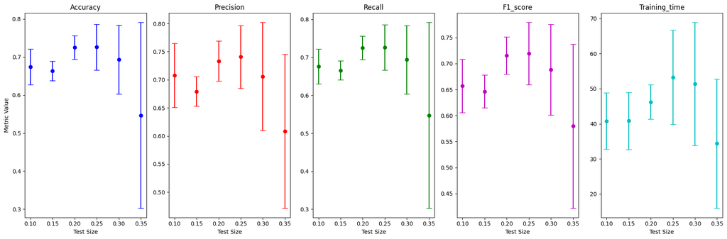

```
Evaluation metrics with standard deviation: {'test_size': [0.1, 0.15, 0.2, 0.25, 0.3, 0.35], 'accuracy': {'mean': [0.6741176470588236, 0.6635294117647059, 0.7252941176470589, 0.7261176470588235, 0.6937254901960784, 0.546890756302521], 'std': [0.04685248882762322, 0.025098039215686294, 0.030768698424…
```

```python
path_name = "models_test_size"

test_sizes = [0.1, 0.15, 0.2, 0.25, 0.3, 0.35]

evaluation_metrics = {
    'test_size': [],
    'accuracy': {'mean': [], 'std': []},
    'precision': {'mean': [], 'std': []},
    'recall': {'mean': [], 'std': []},
    'f1_score': {'mean': [], 'std': []},
    'training_time': {'mean': [], 'std': []}
}

images, labels, one_hot_labels, lb = load_images_from_folder(data_folder, target_size=(16, 16))

for test_size in test_sizes:
    print(f"\nTraining model with {test_size} test size proportion")
    accuracies, precisions, recalls, f1_scores, training_times = [], [], [], [], []

    best_model = None
    best_model_name = None
    best_accuracy = 0
    best_history = None
    best_training_time = None

    for i in range(5):
        X_train_std, X_test_std, y_train, y_test, lb = prepare_train_test_sets(images, labels, test_size=test_size, random_state=42)
        model_name = f"model_testsize_{test_size}_{i}"
        model, history, training_time, num_params, X_test, y_test, lb = create_and_train_model(model, X_train_std, y_train, X_test_std, y_test, lb, X_train_std.shape[1:], y_train.shape[1], path_name, model_name)

        y_pred = model.predict(X_test)
        y_pred_classes = np.argmax(y_pred, axis=1)
        y_true = np.argmax(y_test, axis=1)
        report = classification_report(y_true, y_pred_classes, output_dict=True, zero_division=1)

        accuracies.append(report['accuracy'])
        precisions.append(report['macro avg']['precision'])
        recalls.append(report['macro avg']['recall'])
        f1_scores.append(report['macro avg']['f1-score'])
        training_times.append(training_time)

        current_accuracy = report['accuracy']
        if current_accuracy > best_accuracy:
            best_accuracy = current_accuracy
            best_model = model
            best_model_name = model_name
            best_history = history
            best_training_time = training_time

        print(f"Model {model_name} accuracy: {current_accuracy}")

    evaluation_metrics['test_size'].append(test_size)
    evaluation_metrics['accuracy']['mean'].append(np.mean(accuracies))
    evaluation_metrics['accuracy']['std'].append(np.std(accuracies))
    evaluation_metrics['precision']['mean'].append(np.mean(precisions))
    evaluation_metrics['precision']['std'].append(np.std(precisions))
    evaluation_metrics['recall']['mean'].append(np.mean(recalls))
    evaluation_metrics['recall']['std'].append(np.std(recalls))
    evaluation_metrics['f1_score']['mean'].append(np.mean(f1_scores))
    evaluation_metrics['f1_score']['std'].append(np.std(f1_scores))
    evaluation_metrics['training_time']['mean'].append(np.mean(training_times))
    evaluation_metrics['training_time']['std'].append(np.std(training_times))

    if best_model:
        save_model_and_data(best_model, best_history, best_training_time, num_params, path_name, f"best_model_testsize_{test_size}", X_test, y_test, lb)
        print(f"Saved best model {best_model_name} with accuracy: {best_accuracy}")

plt.figure(figsize=(18, 6))

def plot_with_error(metric_name, subplot_index, color):
    plt.subplot(1, 5, subplot_index)
    plt.errorbar(evaluation_metrics['test_size'],
                 evaluation_metrics[metric_name]['mean'],
                 yerr=evaluation_metrics[metric_name]['std'],
                 fmt='o', ecolor=color, capsize=5, color=color)
    plt.title(metric_name.capitalize())
    plt.xlabel('Test Size')
    if subplot_index == 1:
        plt.ylabel('Metric Value')

plot_with_error('accuracy', 1, 'b')
plot_with_error('precision', 2, 'r')
plot_with_error('recall', 3, 'g')
plot_with_error('f1_score', 4, 'm')
plot_with_error('training_time', 5, 'c')

plt.tight_layout()
plt.show()

print("Evaluation metrics with standard deviation:", evaluation_metrics)
```

## Analysis of Model Performance Based on Test Set Size

### Overview

An experiment was conducted to evaluate how varying the test set size impacts the performance of our CNN model. The test sizes ranged from 10% to 35%, and we measured key performance metrics such as accuracy, precision, recall, F1-score, and training time.

### Assessment of Test Size Modification

- **Optimal Test Size:**
  - The best balance between performance metrics and training time appears to be at a test size of 25%. This configuration provides a good mix of high accuracy and precision, acceptable training time, and consistent model performance. However, we choose to use 20% since the training time is smaller, and std suggests it is more reliable and consistent.
- **Drawbacks of Smaller Training Sets:**
  - Reducing the training set size (e.g., a 35% test size) leads to a notable drop in all performance metrics, indicating that the model struggles with generalization due to insufficient training data. This is a classic symptom of overfitting, where the model performs well on training data but poorly on unseen test data.

### Recommendations and Conclusions

- **Optimal Test Size for Generalization:**
  - Based on the results, a test size of around 20%/25% is recommended for balanced model performance and efficient use of training time. This size provides enough data for the model to learn effectively while retaining a sufficient test set for evaluation.
- **Avoiding Overfitting:**
  - Smaller training sets (resulting from larger test sizes) should be avoided, as they lead to overfitting and reduced model generalization. If limited data is a constraint, techniques like data augmentation or transfer learning might be beneficial.
- **Future Experiments:**
  - Further experiments with additional strategies such as different forms of regularization, more extensive data augmentation, or even exploring more complex model architectures could provide additional insights, especially for test sizes that led to lower performance.

## Evaluation of the Best Models for Different Test Sizes

### Objective

The aim is to evaluate the best-performing models for three different test sizes: `20%`, `25%`, and `30%`. These models were identified as the best in their respective test size categories based on accuracy.

### Models Under Evaluation

- **Selected Models:**
  - `best_model_testsize_0.2`
  - `best_model_testsize_0.25`
  - `best_model_testsize_0.3`

### Evaluation Process

For each selected model, the following steps were undertaken:

1. **Model Loading:**
   - Each model was loaded along with its training history and test data.
2. **Performance Metrics:**
   - We evaluated each model's performance using various metrics such as accuracy, precision, recall, and F1-score. A dataframe `df_report` was generated to tabulate these results.
3. **Visualization and Assessment:**
   - The `plot_and_evaluate_model` function was used to visualize the learning curves and compute a confusion matrix for each model.
4. **Prediction Visualization:**
   - Using the `show_predictions` function, we displayed correctly and incorrectly classified images for each model, along with the probabilities of assigning them to each class. This provides an intuitive understanding of the model's classification behavior.

```
Evaluating best_model_testsize_0.2
```

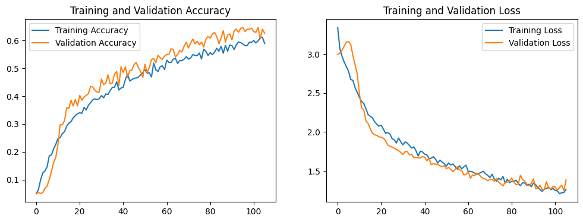

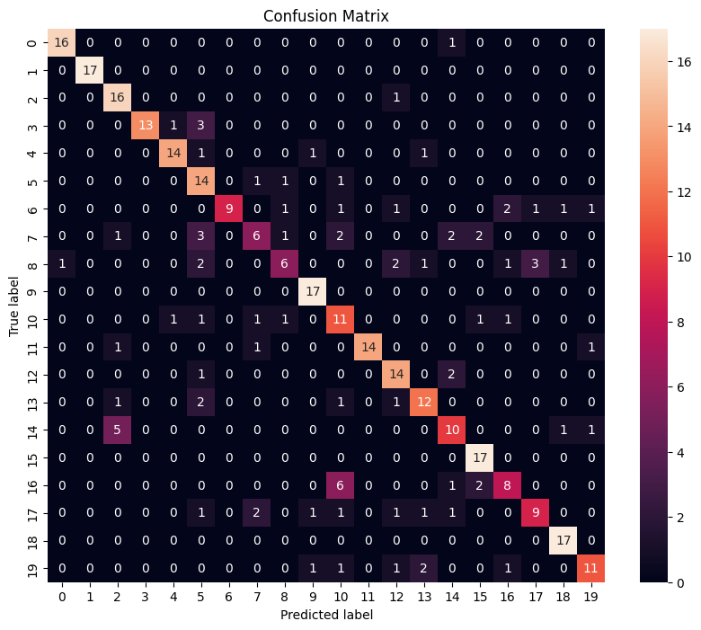

```
[[16  0  0  0  0  0  0  0  0  0  0  0  0  0  1  0  0  0  0  0]
 [ 0 17  0  0  0  0  0  0  0  0  0  0  0  0  0  0  0  0  0  0]
 [ 0  0 16  0  0  0  0  0  0  0  0  0  1  0  0  0  0  0  0  0]
 [ 0  0  0 13  1  3  0  0  0  0  0  0  0  0  0  0  0  0  0  0]
 [ 0  0  0  0 14  1  0  0  0  1  0  0  0  1  0  0  0  0  0  0]
 [ 0  0  0  0  0 14  0  1  1  0  1  0  0  0  0  0  0  0  0  0]
 [ 0  0  0  0  0  0  9  0  1  0  1  0  1  0  0  0  2  1  1  1]
 [ 0  0  1  0  0  3  0  6  1  0  2  0  0  0  2  2  0  0  0  0]
 [ 1  0  0  0  0  2  0  0  6  0  0  0  2  1  0  0  1  3  1  0]
 [ 0  0  0  0  0  0  0  0  0 17  0  0  0  0  0  0  0  0  0  0]
 [ 0  0  0  0  1  1  0  1  1  0 11  0  0  0  0  1  1  0  0  0]
 [ 0  0  1  0  0  0  0  1  0  0  0 14  0  0  0  0  0  0  0  1]
 [ 0  0  0  0  0  1  0  0  0  0  0  0 14  0  2  0  0  0  0  0]
 [ 0  0  1  0  0  2  0  0  0  0  1  0  1 12  0  0  0  0  0  0]
 [ 0  0  5  0  0  0  0  0  0  0  0  0  0  0 10  0  0  0  1  1]
 [ 0  0  0  0  0  0  0  0  0  0  0  0  0  0  0 17  0  0  0  0]
 [ 0  0  0  0  0  0  0  0  0  0  6  0  0  0  1  2  8  0  0  0]
 [ 0  0  0  0  0  1  0  2  0  1  1  0  1  1  1  0  0  9  0  0]
 [ 0  0  0  0  0  0  0  0  0  0  0  0  0  0  0  0  0  0 17  0]
 [ 0  0  0  0  0  0  0  0  0  1  1  0  1  2  0  0  1  0  0 11]]
              precision    recall  f1-score     support
Faces          0.941176  0.941176  0.941176   17.000000
Faces_easy     1.000000  1.000000  1.000000   17.000000
Leopards       0.666667  0.941176  0.780488   17.000000
Motorbikes     1.000000  0.764706  0.866667   17.000000
airplanes      0.875000  0.823529  0.848485   17.000000
bonsai         0.500000  0.823529  0.622222   17.000000
brain          1.000000  0.529412  0.692308   17.000000
buddha         0.545455  0.352941  0.428571   17.000000
butterfly      0.600000  0.352941  0.444444   17.000000
car_side       0.850000  1.000000  0.918919   17.000000
chandelier     0.458333  0.647059  0.536585   17.000000
grand_piano    1.000000  0.823529  0.903226   17.000000
hawksbill      0.666667  0.823529  0.736842   17.000000
helicopter     0.705882  0.705882  0.705882   17.000000
kangaroo       0.588235  0.588235  0.588235   17.000000
ketch          0.772727  1.000000  0.871795   17.000000
menorah        0.615385  0.470588  0.533333   17.000000
starfish       0.692308  0.529412  0.600000   17.000000
trilobite      0.850000  1.000000  0.918919   17.000000
watch          0.785714  0.647059  0.709677   17.000000
accuracy       0.738235  0.738235  0.738235    0.738235
macro avg      0.755677  0.738235  0.732389  340.000000
weighted avg   0.755677  0.738235  0.732389  340.000000
```

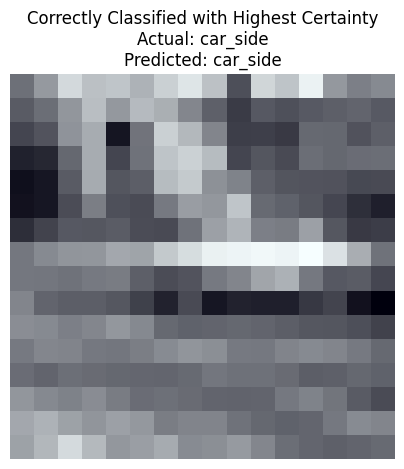

```
Acutal: car_side
Predicted: car_side
Probability of Faces_easy: 0.000001
Probability of airplanes: 0.000063
Probability of bonsai: 0.000021
Probability of buddha: 0.000014
Probability of car_side: 0.999425
Probability of grand_piano: 0.000002
Probability of hawksbill: 0.000021
Probability of helicopter: 0.000434
Probability of kangaroo: 0.000009
Probability of starfish: 0.000003
Probability of trilobite: 0.000002
Probability of watch: 0.000003
```

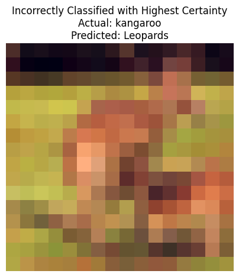

```
Acutal: kangaroo
Predicted: Leopards
Probability of Faces: 0.000030
Probability of Leopards: 0.847141
Probability of airplanes: 0.000044
Probability of bonsai: 0.010557
Probability of brain: 0.000076
Probability of buddha: 0.006031
Probability of butterfly: 0.007517
Probability of car_side: 0.000035
Probability of chandelier: 0.001336
Probability of grand_piano: 0.000125
Probability of hawksbill: 0.007978
Probability of helicopter: 0.001588
Probability of kangaroo: 0.112451
Probability of ketch: 0.000011
Probability of menorah: 0.001305
Probability of starfish: 0.003201
Probability of trilobite: 0.000471
Probability of watch: 0.000104
Evaluating best_model_testsize_0.25
```

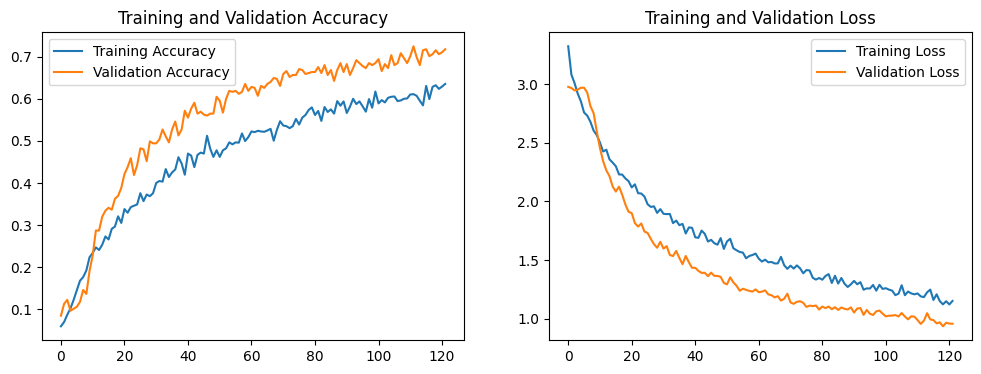

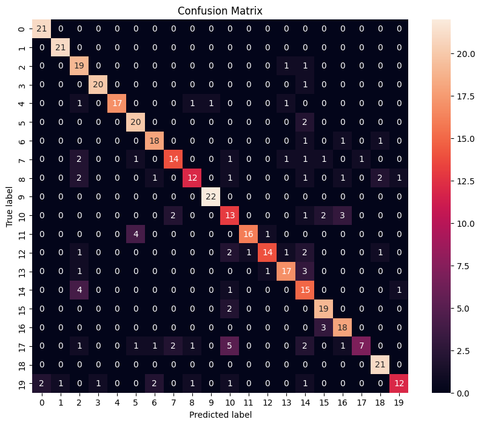

```
[[21  0  0  0  0  0  0  0  0  0  0  0  0  0  0  0  0  0  0  0]
 [ 0 21  0  0  0  0  0  0  0  0  0  0  0  0  0  0  0  0  0  0]
 [ 0  0 19  0  0  0  0  0  0  0  0  0  0  1  1  0  0  0  0  0]
 [ 0  0  0 20  0  0  0  0  0  0  0  0  0  0  1  0  0  0  0  0]
 [ 0  0  1  0 17  0  0  0  1  1  0  0  0  1  0  0  0  0  0  0]
 [ 0  0  0  0  0 20  0  0  0  0  0  0  0  0  2  0  0  0  0  0]
 [ 0  0  0  0  0  0 18  0  0  0  0  0  0  0  1  0  1  0  1  0]
 [ 0  0  2  0  0  1  0 14  0  0  1  0  0  1  1  1  0  1  0  0]
 [ 0  0  2  0  0  0  1  0 12  0  1  0  0  0  1  0  1  0  2  1]
 [ 0  0  0  0  0  0  0  0  0 22  0  0  0  0  0  0  0  0  0  0]
 [ 0  0  0  0  0  0  0  2  0  0 13  0  0  0  1  2  3  0  0  0]
 [ 0  0  0  0  0  4  0  0  0  0  0 16  1  0  0  0  0  0  0  0]
 [ 0  0  1  0  0  0  0  0  0  0  2  1 14  1  2  0  0  0  1  0]
 [ 0  0  1  0  0  0  0  0  0  0  0  0  1 17  3  0  0  0  0  0]
 [ 0  0  4  0  0  0  0  0  0  0  1  0  0  0 15  0  0  0  0  1]
 [ 0  0  0  0  0  0  0  0  0  0  2  0  0  0  0 19  0  0  0  0]
 [ 0  0  0  0  0  0  0  0  0  0  0  0  0  0  0  3 18  0  0  0]
 [ 0  0  1  0  0  1  1  2  1  0  5  0  0  0  2  0  1  7  0  0]
 [ 0  0  0  0  0  0  0  0  0  0  0  0  0  0  0  0  0  0 21  0]
 [ 2  1  0  1  0  0  2  0  1  0  1  0  0  0  1  0  0  0  0 12]]
              precision    recall  f1-score     support
Faces          0.913043  1.000000  0.954545   21.000000
Faces_easy     0.954545  1.000000  0.976744   21.000000
Leopards       0.612903  0.904762  0.730769   21.000000
Motorbikes     0.952381  0.952381  0.952381   21.000000
airplanes      1.000000  0.809524  0.894737   21.000000
bonsai         0.769231  0.909091  0.833333   22.000000
brain          0.818182  0.857143  0.837209   21.000000
buddha         0.777778  0.636364  0.700000   22.000000
butterfly      0.800000  0.571429  0.666667   21.000000
car_side       0.956522  1.000000  0.977778   22.000000
chandelier     0.500000  0.619048  0.553191   21.000000
grand_piano    0.941176  0.761905  0.842105   21.000000
hawksbill      0.875000  0.636364  0.736842   22.000000
helicopter     0.809524  0.772727  0.790698   22.000000
kangaroo       0.483871  0.714286  0.576923   21.000000
ketch          0.760000  0.904762  0.826087   21.000000
menorah        0.750000  0.857143  0.800000   21.000000
starfish       0.875000  0.333333  0.482759   21.000000
trilobite      0.840000  1.000000  0.913043   21.000000
watch          0.857143  0.571429  0.685714   21.000000
accuracy       0.790588  0.790588  0.790588    0.790588
macro avg      0.812315  0.790584  0.786576  425.000000
weighted avg   0.812613  0.790588  0.786825  425.000000
```

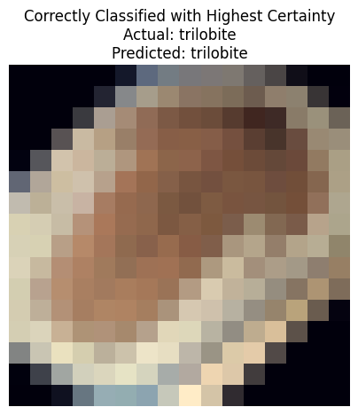

```
Acutal: trilobite
Predicted: trilobite
Probability of brain: 0.000106
Probability of butterfly: 0.000066
Probability of hawksbill: 0.000020
Probability of trilobite: 0.999809
```

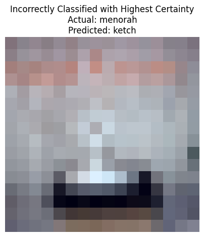

```
Acutal: menorah
Predicted: ketch
Probability of Faces: 0.000132
Probability of Leopards: 0.000073
Probability of Motorbikes: 0.000015
Probability of airplanes: 0.000692
Probability of bonsai: 0.000001
Probability of brain: 0.000839
Probability of buddha: 0.000745
Probability of butterfly: 0.000266
Probability of car_side: 0.000002
Probability of chandelier: 0.006224
Probability of hawksbill: 0.000280
Probability of helicopter: 0.010477
Probability of kangaroo: 0.000096
Probability of ketch: 0.969345
Probability of menorah: 0.008480
Probability of starfish: 0.002021
Probability of watch: 0.000311
Evaluating best_model_testsize_0.3
```

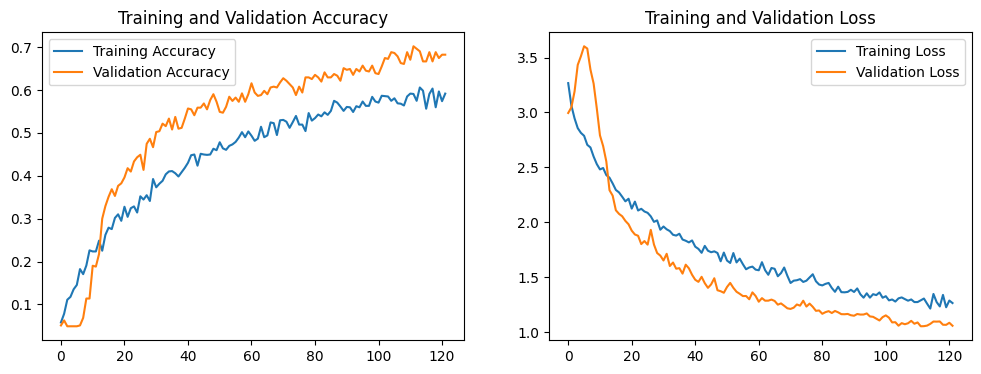

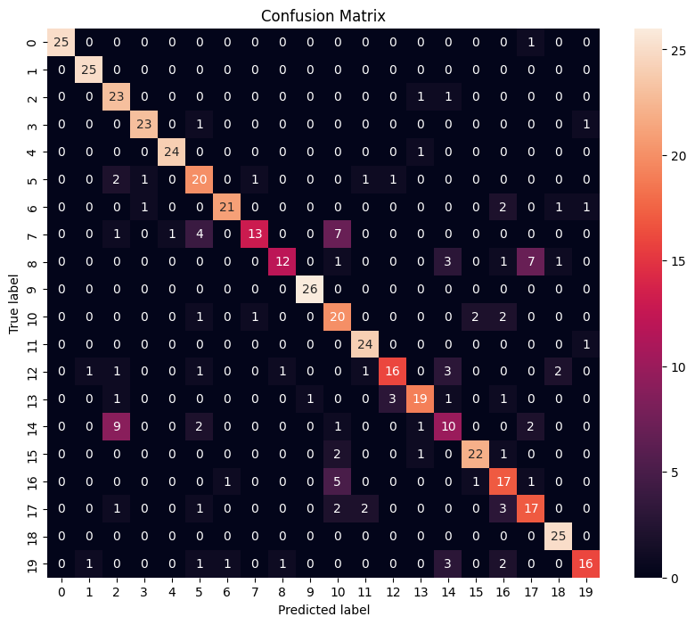

```
[[25  0  0  0  0  0  0  0  0  0  0  0  0  0  0  0  0  1  0  0]
 [ 0 25  0  0  0  0  0  0  0  0  0  0  0  0  0  0  0  0  0  0]
 [ 0  0 23  0  0  0  0  0  0  0  0  0  0  1  1  0  0  0  0  0]
 [ 0  0  0 23  0  1  0  0  0  0  0  0  0  0  0  0  0  0  0  1]
 [ 0  0  0  0 24  0  0  0  0  0  0  0  0  1  0  0  0  0  0  0]
 [ 0  0  2  1  0 20  0  1  0  0  0  1  1  0  0  0  0  0  0  0]
 [ 0  0  0  1  0  0 21  0  0  0  0  0  0  0  0  0  2  0  1  1]
 [ 0  0  1  0  1  4  0 13  0  0  7  0  0  0  0  0  0  0  0  0]
 [ 0  0  0  0  0  0  0  0 12  0  1  0  0  0  3  0  1  7  1  0]
 [ 0  0  0  0  0  0  0  0  0 26  0  0  0  0  0  0  0  0  0  0]
 [ 0  0  0  0  0  1  0  1  0  0 20  0  0  0  0  2  2  0  0  0]
 [ 0  0  0  0  0  0  0  0  0  0  0 24  0  0  0  0  0  0  0  1]
 [ 0  1  1  0  0  1  0  0  1  0  0  1 16  0  3  0  0  0  2  0]
 [ 0  0  1  0  0  0  0  0  0  1  0  0  3 19  1  0  1  0  0  0]
 [ 0  0  9  0  0  2  0  0  0  0  1  0  0  1 10  0  0  2  0  0]
 [ 0  0  0  0  0  0  0  0  0  0  2  0  0  1  0 22  1  0  0  0]
 [ 0  0  0  0  0  0  1  0  0  0  5  0  0  0  0  1 17  1  0  0]
 [ 0  0  1  0  0  1  0  0  0  0  2  2  0  0  0  0  3 17  0  0]
 [ 0  0  0  0  0  0  0  0  0  0  0  0  0  0  0  0  0  0 25  0]
 [ 0  1  0  0  0  1  1  0  1  0  0  0  0  0  3  0  2  0  0 16]]
              precision    recall  f1-score     support
Faces          1.000000  0.961538  0.980392   26.000000
Faces_easy     0.925926  1.000000  0.961538   25.000000
Leopards       0.605263  0.920000  0.730159   25.000000
Motorbikes     0.920000  0.920000  0.920000   25.000000
airplanes      0.960000  0.960000  0.960000   25.000000
bonsai         0.645161  0.769231  0.701754   26.000000
brain          0.913043  0.807692  0.857143   26.000000
buddha         0.866667  0.500000  0.634146   26.000000
butterfly      0.857143  0.480000  0.615385   25.000000
car_side       0.962963  1.000000  0.981132   26.000000
chandelier     0.526316  0.769231  0.625000   26.000000
grand_piano    0.857143  0.960000  0.905660   25.000000
hawksbill      0.800000  0.615385  0.695652   26.000000
helicopter     0.826087  0.730769  0.775510   26.000000
kangaroo       0.476190  0.400000  0.434783   25.000000
ketch          0.880000  0.846154  0.862745   26.000000
menorah        0.586207  0.680000  0.629630   25.000000
starfish       0.607143  0.653846  0.629630   26.000000
trilobite      0.862069  1.000000  0.925926   25.000000
watch          0.842105  0.640000  0.727273   25.000000
accuracy       0.780392  0.780392  0.780392    0.780392
macro avg      0.795971  0.780692  0.777673  510.000000
weighted avg   0.796104  0.780392  0.777607  510.000000
```

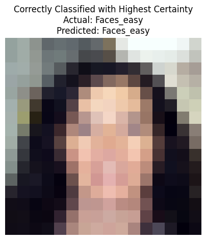

```
Acutal: Faces_easy
Predicted: Faces_easy
Probability of Faces: 0.000029
Probability of Faces_easy: 0.999827
Probability of buddha: 0.000003
Probability of trilobite: 0.000004
Probability of watch: 0.000134
```

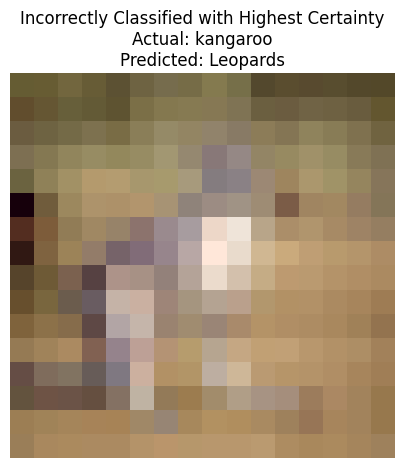

```
Acutal: kangaroo
Predicted: Leopards
Probability of Faces: 0.000009
Probability of Leopards: 0.889146
Probability of airplanes: 0.000057
Probability of bonsai: 0.002200
Probability of brain: 0.000011
Probability of buddha: 0.021222
Probability of butterfly: 0.001493
Probability of car_side: 0.000093
Probability of chandelier: 0.012154
Probability of grand_piano: 0.000010
Probability of hawksbill: 0.003844
Probability of helicopter: 0.004213
Probability of kangaroo: 0.055042
Probability of ketch: 0.000076
Probability of menorah: 0.005787
Probability of starfish: 0.004063
Probability of trilobite: 0.000001
Probability of watch: 0.000579
```

```python
best_model_names = ['best_model_testsize_0.2', 'best_model_testsize_0.25', 'best_model_testsize_0.3']
for model_name in best_model_names:
    print(f"Evaluating {model_name}")
    model, history, X_test_std, y_test, lb = load_model_and_history(path_name, model_name)
    df_report = plot_and_evaluate_model(model, history, X_test_std, y_test, lb)
    print(df_report)
    show_predictions(model, X_test_std, y_test, lb, correctly_classified_images=1, incorrectly_classified_images=1)
```

## Comparative Analysis of the Best Models for Different Test Sizes

### Overview

We evaluated three models with different test sizes - `20%`, `25%`, and `30%`. Here's a detailed analysis comparing their performance based on various aspects.

### Predictive Ability

- **Model with 20% Test Size:** Showed a balanced performance across various classes with some misclassifications. The accuracy, precision, and recall rates are moderate.
- **Model with 25% Test Size:** Demonstrated a higher accuracy in classifying certain classes like `car_side` and `Faces`, but struggled with classes like `buddha` and `butterfly`.
- **Model with 30% Test Size:** Had a good performance in classes like `trilobite` and `Faces_easy`, but lower accuracy in classes like `kangaroo` and `buddha`.

### Learning Duration and Model Complexity

- The training times were 54.49s, 72.39s, and 58.29s for the 20%, 25%, and 30% test size models, respectively. The model with a 25% test size took the longest, potentially due to more extensive data processing.
- All models had the same number of parameters (43,204), indicating that the complexity of the models remained constant across different test sizes.

### Recommendations and Best Model Selection

- **Best Model:** Considering the balance between accuracy, learning stability, and training duration, the model with a 25% test size seems to be the most effective. It strikes a good balance between learning efficiency and predictive performance.
- **Recommendations:** For further improvement, it would be worthwhile to investigate more targeted strategies to reduce overfitting, such as fine-tuning dropout rates or implementing early stopping.
- **Future Experiments:** Additional experiments with different proportions of test sizes or more advanced regularization techniques could provide further insights into the optimal configuration for this specific problem.

## Experiment: Effect of Dropout Rates on Model Performance

### Objective

This experiment aims to explore the impact of different dropout rates on the performance of a Convolutional Neural Network (CNN) model. Dropout is a regularization technique used to prevent overfitting by randomly dropping units (neurons) from the neural network during training.

### Methodology

- **Dropout Variations:**
  - We varied the dropout rates as `0.1`, `0.2`, `0.3`, `0.4`, `0.5`, and `0.6` to understand how dropout influences the model's ability to generalize.
- **Model Training:**
  - For each dropout rate, we trained a CNN model with a fixed number of epochs and monitored its performance on a validation set.
- **Performance Metrics:**
  - We measured accuracy, precision, recall, and F1-score for each model. These metrics provide a comprehensive view of the model's performance across different dropout rates.
- **Training Setup:**
  - All models were trained with the same training data, epochs, and other hyperparameters (except for the dropout rate) to ensure a fair comparison.

### Results Visualization

- **Metric Comparison:**
  - We plotted the performance metrics against the dropout rates to observe the trends and identify the optimal dropout rate.

### Observations

- **Impact on Performance:**
  - The plots show how each performance metric is influenced by different dropout rates. A suitable dropout rate can improve model generalization by reducing overfitting.
- **Optimal Dropout Rate:**
  - We expect to find a dropout rate that provides the best balance between learning and regularization, as evidenced by the highest values in accuracy and F1-score.

### Conclusions and Insights

- **Finding the Balance:**
  - The experiment will help in determining the dropout rate that effectively balances between underfitting and overfitting.
- **Model Robustness:**
  - A proper dropout rate can enhance the model's robustness, making it more reliable when exposed to new, unseen data.
- **Further Research:**
  - Additional experiments might include varying other hyperparameters in conjunction with dropout rates to further refine the model.

```
Training model with 0.1 dropout rate
Loading existing model...
Model model_dropout_0.1_0 accuracy: 0.5929411764705882
Loading existing model...
Model model_dropout_0.1_1 accuracy: 0.7341176470588235
Loading existing model...
Model model_dropout_0.1_2 accuracy: 0.8117647058823529
Loading existing model...
Model model_dropout_0.1_3 accuracy: 0.7811764705882352
Loading existing model...
Model model_dropout_0.1_4 accuracy: 0.6847058823529412
Model best_model_dropout_0.1 saved successfully.
Data for best_model_dropout_0.1 saved successfully.
Saved best model model_dropout_0.1_2 with accuracy: 0.8117647058823529

Training model with 0.2 dropout rate
Loading existing model...
Model model_dropout_0.2_0 accuracy: 0.6894117647058824
Loading existing model...
Model model_dropout_0.2_1 accuracy: 0.5811764705882353
Loading existing model...
Model model_dropout_0.2_2 accuracy: 0.7623529411764706
Loading existing model...
Model model_dropout_0.2_3 accuracy: 0.7811764705882352
Loading existing model...
Model model_dropout_0.2_4 accuracy: 0.5129411764705882
Model best_model_dropout_0.2 saved successfully.
Data for best_model_dropout_0.2 saved successfully.
Saved best model model_dropout_0.2_3 with accuracy: 0.7811764705882352

Training model with 0.3 dropout rate
Loading existing model...
Model model_dropout_0.3_0 accuracy: 0.6894117647058824
Loading existing model...
Model model_dropout_0.3_1 accuracy: 0.6752941176470588
Loading existing model...
Model model_dropout_0.3_2 accuracy: 0.7482352941176471
Loading existing model...
Model model_dropout_0.3_3 accuracy: 0.7482352941176471
Loading existing model...
```

[output cut: 34 more lines]

```

Training model with 0.6 dropout rate
Loading existing model...
Model model_dropout_0.6_0 accuracy: 0.7270588235294118
Loading existing model...
Model model_dropout_0.6_1 accuracy: 0.691764705882353
Loading existing model...
Model model_dropout_0.6_2 accuracy: 0.6305882352941177
Loading existing model...
Model model_dropout_0.6_3 accuracy: 0.6023529411764705
Loading existing model...
Model model_dropout_0.6_4 accuracy: 0.7811764705882352
Model best_model_dropout_0.6 saved successfully.
Data for best_model_dropout_0.6 saved successfully.
Saved best model model_dropout_0.6_4 with accuracy: 0.7811764705882352
```

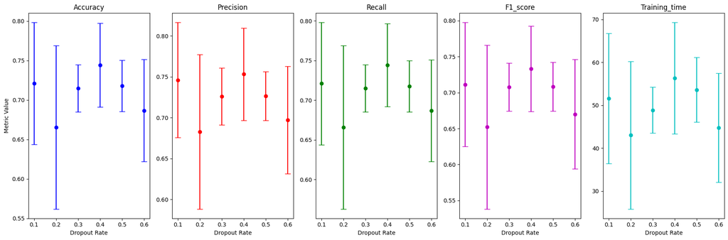

```
Evaluation metrics with standard deviation: {'dropout_rate': [0.1, 0.2, 0.3, 0.4, 0.5, 0.6], 'accuracy': {'mean': [0.7209411764705882, 0.6654117647058824, 0.7148235294117647, 0.744, 0.7176470588235294, 0.6865882352941177], 'std': [0.07713341697241755, 0.10365126518806465, 0.02981465235097819, 0.0529…
```

```python
path_name = "models_dropout"

dropout_rates = [0.1, 0.2, 0.3, 0.4, 0.5, 0.6]

evaluation_metrics = {
    'dropout_rate': [],
    'accuracy': {'mean': [], 'std': []},
    'precision': {'mean': [], 'std': []},
    'recall': {'mean': [], 'std': []},
    'f1_score': {'mean': [], 'std': []},
    'training_time': {'mean': [], 'std': []}
}

images, labels, one_hot_labels, lb = load_images_from_folder(data_folder, target_size=(16, 16))

for dropout_rate in dropout_rates:
    print(f"\nTraining model with {dropout_rate} dropout rate")
    accuracies, precisions, recalls, f1_scores, training_times = [], [], [], [], []

    best_model = None
    best_model_name = None
    best_accuracy = 0
    best_history = None
    best_training_time = None

    for i in range(5):
        X_train_std, X_test_std, y_train, y_test, lb = prepare_train_test_sets(images, labels, test_size=0.25, random_state=42)
        model_name = f"model_dropout_{dropout_rate}_{i}"
        model, history, training_time, num_params, X_test, y_test, lb = create_and_train_model(model, X_train_std, y_train, X_test_std, y_test, lb, X_train_std.shape[1:], y_train.shape[1], path_name, model_name, dropout_rate=dropout_rate)

        y_pred = model.predict(X_test)
        y_pred_classes = np.argmax(y_pred, axis=1)
        y_true = np.argmax(y_test, axis=1)
        report = classification_report(y_true, y_pred_classes, output_dict=True, zero_division=1)

        accuracies.append(report['accuracy'])
        precisions.append(report['macro avg']['precision'])
        recalls.append(report['macro avg']['recall'])
        f1_scores.append(report['macro avg']['f1-score'])
        training_times.append(training_time)

        current_accuracy = report['accuracy']
        if current_accuracy > best_accuracy:
            best_accuracy = current_accuracy
            best_model = model
            best_model_name = model_name
            best_history = history
            best_training_time = training_time

        print(f"Model {model_name} accuracy: {current_accuracy}")

    evaluation_metrics['dropout_rate'].append(dropout_rate)
    evaluation_metrics['accuracy']['mean'].append(np.mean(accuracies))
    evaluation_metrics['accuracy']['std'].append(np.std(accuracies))
    evaluation_metrics['precision']['mean'].append(np.mean(precisions))
    evaluation_metrics['precision']['std'].append(np.std(precisions))
    evaluation_metrics['recall']['mean'].append(np.mean(recalls))
    evaluation_metrics['recall']['std'].append(np.std(recalls))
    evaluation_metrics['f1_score']['mean'].append(np.mean(f1_scores))
    evaluation_metrics['f1_score']['std'].append(np.std(f1_scores))
    evaluation_metrics['training_time']['mean'].append(np.mean(training_times))
    evaluation_metrics['training_time']['std'].append(np.std(training_times))

    if best_model:
        save_model_and_data(best_model, best_history, best_training_time, num_params, path_name, f"best_model_dropout_{dropout_rate}", X_test, y_test, lb)
        print(f"Saved best model {best_model_name} with accuracy: {best_accuracy}")

plt.figure(figsize=(18, 6))

def plot_with_error(metric_name, subplot_index, color):
    plt.subplot(1, 5, subplot_index)
    plt.errorbar(evaluation_metrics['dropout_rate'],
                    evaluation_metrics[metric_name]['mean'],
                    yerr=evaluation_metrics[metric_name]['std'],
                    fmt='o', ecolor=color, capsize=5, color=color)
    plt.title(metric_name.capitalize())
    plt.xlabel('Dropout Rate')
    if subplot_index == 1:
        plt.ylabel('Metric Value')

plot_with_error('accuracy', 1, 'b')
plot_with_error('precision', 2, 'r')
plot_with_error('recall', 3, 'g')
plot_with_error('f1_score', 4, 'm')
plot_with_error('training_time', 5, 'c')

plt.tight_layout()
plt.show()

print("Evaluation metrics with standard deviation:", evaluation_metrics)
```

## Analysis of Dropout Rate Experiment Results

### Overview

In this experiment, we explored the impact of various dropout rates on a Convolutional Neural Network's performance. Dropout rates ranged from 0.1 to 0.6. The evaluation focused on the model's predictive ability, training duration, model complexity, and the benefits of applying different dropout rates.

### Profitability of Modification

- **Effectiveness:**
  - Implementing dropout proved effective in enhancing model performance, with the `0.4` dropout rate yielding the best balance between accuracy and generalization.
- **Optimal Dropout Rate:**
  - A dropout rate of `0.4` is recommended based on these results, considering its superior performance across multiple metrics.